# Machine Learning Final Project

### 106000147 沈永聖 106061146 陳兆廷

## Captcha Breaker using Residual CNN

[figure not shown]

```python
%matplotlib inline
```

```python
from time import sleep
import pandas as pd
import requests
import json
from PIL import Image
from base64 import b64encode,b64decode
from io import BytesIO
from bs4 import BeautifulSoup
import threading
from requests.adapters import HTTPAdapter

img_flag = False
token_flag = False
read_time = 20
delay = 0.1
s = requests.session()
s.mount('http://', HTTPAdapter(max_retries=30))
s.mount('https://', HTTPAdapter(max_retries=30))

while token_flag == False:
    try:
        r =s.get("https://youthdream.phdf.org.tw/member/login",timeout=read_time)
        if r.status_code == 200:
            soup = BeautifulSoup(r.text, 'html.parser')
            _token = soup.select_one('input[name = "_token"]')['value']
            token_flag = True
        sleep(delay)
    except:
        None

## get cpatcha_url
_ = soup.select_one('a[id = "captcha"]').select_one('img')
captcha_url = _["src"]

for i in range(1000,1003):
    ## get captcha_img
    img_flag = False
    while img_flag == False:
        try:
            cap_img =s.get(captcha_url,timeout=read_time)
            if cap_img.status_code == 200:
                image = Image.open(BytesIO(cap_img.content))
                image = image.convert('RGB')
                img_flag = True
                image.save('./data/captcha_original/jpg/'+str(i)+'.jpg')
        except:
            None
```

上面的步驟會將爬到的圖片存入captcha_original的資料夾內，但沒有答案（label）。  
所以我們只好手動label...

### 說明

1. i的範圍為要label的檔案名稱範圍(因為是用數字儲存)。
2. resize圖片大小為160,60。
3. 輸入正確的驗證碼並另外儲存。

```
1000
```

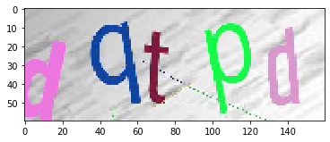

```
dqtpd
```

```python
import matplotlib.pyplot as plt
%matplotlib inline
#folder = "5_trans_set/"
folder = "5_captc_rel/"                  #存在哪
filename_list = []
for i in range(1000,1001):           #這只是測試 寫一個就好
    print(i)
    im = Image.open('./data/captcha_original/jpg/'+str(i)+'.jpg')
    im = im.resize((160,60))
    plt.imshow(im)
    plt.show()
    file_name = input()
    im.save('./data/'+folder+file_name+'.jpg')
    plt.clf()
```

因此總共有1000筆的目標網站Train data，及200筆的Test data。（手動label花了3～4小時）

[figure not shown]

### 觀察

在重複了無數次label的過程中發現了一些規則，

1. 有大約9種背景(底圖)。
2. 3、4種字形。
3. 字體有位移跟旋轉。
4. 字體顏色變化。
5. 干擾線存在(從adversarial attack的概念中可以得知即使是一點的干擾也能對model造成莫大的影響)。
6. 並非36英數字都使用，只使用其中28種。

在第六點中未出現的8種英數字為*0、1、5、i、o、s、v、w*(有時候會看到像i的字母是因為j位移、旋轉而使得尾巴部分消失)，因此在model預測時並非預測36個機率，而是預測28個，這能有效提升model的正確性。

並且使用captcha_gen.py時將上述規則套用進去，以產生跟目標網站有著相同英數字的驗證碼。

#### 總而言之，dataset有：

1. 70000筆 train data 五碼圖像驗證碼 genarate出來的
2. 1000筆 train data 目標網站的驗證碼 爬下來的自己label的
3. 200筆 test data 目標網站的驗證碼 爬下來的自己label的

### DataLoader

建立dataloader，並對資料進行處理

#### 步驟

1. 將圖片轉為tensor
2. 將5碼驗證碼分開，視作5個子label，並使用one hot encoder
3. 設定batch_size、shuffle

## 附註

由於每個電腦路徑不一定相同，因此image_name的index有時候要改變才能正確運作。

```python
# -*- coding: UTF-8 -*-
import os
from torch.utils.data import DataLoader,Dataset
import torchvision.transforms as transforms
from PIL import Image
import csv
import numpy as np

class mydataset(Dataset):

    def __init__(self, folder, transform=None):
        self.train_image_file_paths = [os.path.join(folder, image_file) for image_file in os.listdir(folder)]
        self.transform = transform

    def __len__(self):
        return len(self.train_image_file_paths)

    def __getitem__(self, idx):
        image_root = self.train_image_file_paths[idx]
        image_name = image_root.split(os.path.sep)[-1]
        image = Image.open(image_root)
        if self.transform is not None:
            image = self.transform(image)

        label1 = toonehot(image_name[19])
        label2 = toonehot(image_name[20])
        label3 = toonehot(image_name[21])
        label4 = toonehot(image_name[22])
        label5 = toonehot(image_name[23])
        label = {
            'label1':label1,
            'label2':label2,
            'label3':label3,
            'label4':label4,
            'label5':label5
        }
        return image, label

transform = transforms.Compose([
    transforms.ToTensor(),
])


LETTERSTR = "2346789abcdefghjklmnpqrtuxyz"
def toonehot(text):
    labellist = []
    for letter in text:
        onehot = np.zeros(28, dtype=float)
        #onehot = [0 for _ in range(36)]
        num = LETTERSTR.find(letter)
        onehot[num] = 1.0
    return onehot

def get_train_data_loader():

    dataset = mydataset("./data/5_train_set/", transform=transform)
    return DataLoader(dataset, batch_size=32, shuffle=True)


def get_predict_data_loader():
    dataset = mydataset('./data/5_captc_rel/', transform=transform)
    return DataLoader(dataset, batch_size=1, shuffle=True)

def get_transfer_data_loader():
    dataset = mydataset('./data/5_trans_set/', transform=transform)
    return DataLoader(dataset, batch_size=8, shuffle=True)
```

## Method & Model

我們是引用[臺鐵驗證碼CNN辨識器](https://github.com/JasonLiTW/simple-railway-captcha-solver)的model加以改良。  
第一個Model是將這個Model從tensorflow轉為PyTorch版本，在GPU上運行較快。

### Model說明

1. Convolution layer : 作為filter一般存在，提取出image的特徵。通常深度越深，提取出來的Feature會越全面。為使計算輛不過於龐大，使用的kernel_size為3。
2. pooling layer : 減少運算的資料量，並且增加receptive field。
3. Dropout : 使用的機率為0.3，作為減少運算量與regulation的存在。
4. BatchNorm2d : 減少資料的variance與bias，並能加快converge。
5. flatten : 將資料變成一維，方便prediction。
6. output_layer : 每個output layer個別有著lieanr layer與softmax用作從CNN layers提取出來的features做運算與預測，五個layer分別對應captcha的一個position。

```python
# -*- coding: UTF-8 -*-
import torch.nn as nn
import torch
# CNN Model (2 conv layer)

class CNN(nn.Module):
    def __init__(self):
        super(CNN, self).__init__()
        self.layer1 = nn.Sequential(
            nn.Conv2d(3, 32, kernel_size=3, padding=1),
            nn.ReLU())
        self.layer2 = nn.Sequential(
            nn.Conv2d(32, 32, kernel_size=3),
            nn.ReLU(),
            nn.BatchNorm2d(32),
            nn.MaxPool2d(2),
            nn.Dropout(0.3))
        self.layer3 = nn.Sequential(
            nn.Conv2d(32, 64, kernel_size=3, padding=1),
            nn.ReLU())
        self.layer4 = nn.Sequential(
            nn.Conv2d(64, 64, kernel_size=3),
            nn.ReLU(),
            nn.BatchNorm2d(64),
            nn.MaxPool2d(2),
            nn.Dropout(0.3))
        self.layer5 = nn.Sequential(
            nn.Conv2d(64, 128, kernel_size=3, padding=1),
            nn.ReLU())
        self.layer6 = nn.Sequential(
            nn.Conv2d(128, 128, kernel_size=3),
            nn.ReLU(),
            nn.BatchNorm2d(128),
            nn.MaxPool2d(2),
            nn.Dropout(0.3))
        self.layer7= nn.Sequential(
            nn.Conv2d(128, 256, kernel_size=3),
            nn.ReLU(),
            nn.BatchNorm2d(256),
            nn.MaxPool2d(2),
            nn.Flatten(),
            nn.Dropout(0.3))
        self.out_layer1 = nn.Sequential(
            nn.Linear(2048,28),
            nn.Softmax(1)
           )
        self.out_layer2 = nn.Sequential(
            nn.Linear(2048,28),
            nn.Softmax(1)
           )
        self.out_layer3 = nn.Sequential(
            nn.Linear(2048,28),
            nn.Softmax(1)
           )
        self.out_layer4 = nn.Sequential(
            nn.Linear(2048,28),
            nn.Softmax(1)
           )
        self.out_layer5 = nn.Sequential(
            nn.Linear(2048,28),
            nn.Softmax(1)
           )

    def forward(self, x):
        out = self.layer1(x)
        out = self.layer2(out)
        out = self.layer3(out)
        out = self.layer4(out)
        out = self.layer5(out)
        out = self.layer6(out)
        out = self.layer7(out)
        out1 = self.out_layer1(out)
        out2 = self.out_layer2(out)
        out3 = self.out_layer3(out)
        out4 = self.out_layer4(out)
        out5 = self.out_layer5(out)

        return out1,out2,out3,out4,out5

model = CNN()
if torch.cuda.is_available():
    model.cuda()

from torchsummary import summary
summary(model, input_size=(3, 60, 160))
```

```
----------------------------------------------------------------
        Layer (type)               Output Shape         Param #
================================================================
            Conv2d-1          [-1, 32, 60, 160]             896
              ReLU-2          [-1, 32, 60, 160]               0
            Conv2d-3          [-1, 32, 58, 158]           9,248
              ReLU-4          [-1, 32, 58, 158]               0
       BatchNorm2d-5          [-1, 32, 58, 158]              64
         MaxPool2d-6           [-1, 32, 29, 79]               0
           Dropout-7           [-1, 32, 29, 79]               0
            Conv2d-8           [-1, 64, 29, 79]          18,496
              ReLU-9           [-1, 64, 29, 79]               0
           Conv2d-10           [-1, 64, 27, 77]          36,928
             ReLU-11           [-1, 64, 27, 77]               0
      BatchNorm2d-12           [-1, 64, 27, 77]             128
        MaxPool2d-13           [-1, 64, 13, 38]               0
          Dropout-14           [-1, 64, 13, 38]               0
           Conv2d-15          [-1, 128, 13, 38]          73,856
             ReLU-16          [-1, 128, 13, 38]               0
           Conv2d-17          [-1, 128, 11, 36]         147,584
             ReLU-18          [-1, 128, 11, 36]               0
      BatchNorm2d-19          [-1, 128, 11, 36]             256
        MaxPool2d-20           [-1, 128, 5, 18]               0
          Dropout-21           [-1, 128, 5, 18]               0
           Conv2d-22           [-1, 256, 3, 16]         295,168
             ReLU-23           [-1, 256, 3, 16]               0
      BatchNorm2d-24           [-1, 256, 3, 16]             512
        MaxPool2d-25            [-1, 256, 1, 8]               0
          Flatten-26                 [-1, 2048]               0
          Dropout-27                 [-1, 2048]               0
           Linear-28                   [-1, 28]          57,372
          Softmax-29                   [-1, 28]               0
           Linear-30                   [-1, 28]          57,372
          Softmax-31                   [-1, 28]               0
           Linear-32                   [-1, 28]          57,372
          Softmax-33                   [-1, 28]               0
           Linear-34                   [-1, 28]          57,372
          Softmax-35                   [-1, 28]               0
           Linear-36                   [-1, 28]          57,372
          Softmax-37                   [-1, 28]               0
================================================================
Total params: 869,996
Trainable params: 869,996
Non-trainable params: 0
----------------------------------------------------------------
Input size (MB): 0.11
Forward/backward pass size (MB): 20.91
Params size (MB): 3.32
Estimated Total Size (MB): 24.34
----------------------------------------------------------------
```

## Model Training

*Hyper Parameter的調整（Pre-train）：（同時與下一個Module ResCNN 的Parameter相同，以利比較）*

1. num_epochs = 70——在深度及我們電腦能運行的速度取得之值
2. learning_rate = 0.001——Loss在遞減時的速度，在運行幾次後得到最好的module之下的結果。
3. batch_size = 32——選用2的指數倍以增加記憶體使用效率。

*Hyper Parameter的調整（train）：*

1. num_epochs = 500——在深度及我們電腦能運行的速度取得之值，這次train的dataset為1000筆，可以Train比較久。
2. learning_rate = 0.001——Loss在遞減時的速度，在運行幾次後得到最好的module之下的結果。
3. batch_size = 8——因為收集的資料量少，因此batch_size選用較小的量。

```python
import os
os.environ['CUDA_VISIBLE_DEVICES']='2, 3'
# -*- coding: UTF-8 -*-
import torch
import torch.nn as nn
from torch.autograd import Variable
import pytorch_dataset
from pytorch_model import CNN
import pandas as pd

# Hyper Parameters
num_epochs = 70
learning_rate = 0.001
use_cuda=True
def main():
    losses=[]
    device = torch.device("cuda" if (use_cuda and torch.cuda.is_available()) else "cpu")
    cnn = CNN().to(device)
    cnn.train()
    print('init net')
    criterion = nn.CrossEntropyLoss()
    optimizer = torch.optim.Adam(cnn.parameters(), lr=learning_rate)

    # Train the Model
    train_dataloader = pytorch_dataset.get_train_data_loader()
    for epoch in range(num_epochs):
        for i, (images, labels) in enumerate(train_dataloader):
            images = Variable(images).to(device)
            labels1 = Variable(labels['label1'].float()).to(device)
            labels2 = Variable(labels['label2'].float()).to(device)
            labels3 = Variable(labels['label3'].float()).to(device)
            labels4 = Variable(labels['label4'].float()).to(device)
            labels5 = Variable(labels['label5'].float()).to(device)
            out1,out2,out3,out4, out5 = cnn(images)
            #out = cnn(images)

            # print(predict_labels.type)
            # print(labels.type)
            loss1 = criterion(out1, torch.max(labels1, 1)[1])
            loss2 = criterion(out2, torch.max(labels2, 1)[1])
            loss3 = criterion(out3, torch.max(labels3, 1)[1])
            loss4 = criterion(out4, torch.max(labels4, 1)[1])
            loss5 = criterion(out5, torch.max(labels5, 1)[1])
            loss = (loss1+loss2+loss3+loss4+loss5)
            optimizer.zero_grad()
            loss.backward()
            optimizer.step()
            if (i+1) % 10 == 0:
                print("epoch:", epoch, "step:", i+1, "loss:", loss.item())
                losses.append( loss.item())
            if (i+1) % 100 == 0:
                torch.save(cnn.state_dict(), "./pkl/model.pkl")   #current is model.pkl
                print("save model")
        print("epoch:", epoch, "step:", i, "loss:", loss.item())
    torch.save(cnn.state_dict(), "./pkl/model.pkl")   #current is model.pkl
    print("save last model")
    df = pd.DataFrame(losses, columns = ["loss"])
    df.to_csv('./loss/CNN_loss.csv')

if __name__ == '__main__':
    main()
```

```
init net
epoch: 0 step: 10 loss: 16.691835403442383
epoch: 0 step: 20 loss: 16.707347869873047
epoch: 0 step: 30 loss: 16.72922706604004
epoch: 0 step: 40 loss: 16.73739242553711
epoch: 0 step: 50 loss: 16.813640594482422
epoch: 0 step: 60 loss: 16.669313430786133
epoch: 0 step: 70 loss: 16.6280517578125
epoch: 0 step: 80 loss: 16.696086883544922
epoch: 0 step: 90 loss: 16.66120719909668
epoch: 0 step: 100 loss: 16.67246437072754
save model
epoch: 0 step: 110 loss: 16.658931732177734
epoch: 0 step: 120 loss: 16.61366844177246
epoch: 0 step: 130 loss: 16.760305404663086
epoch: 0 step: 140 loss: 16.67780876159668
epoch: 0 step: 150 loss: 16.72141456604004
epoch: 0 step: 160 loss: 16.637130737304688
epoch: 0 step: 170 loss: 16.68821907043457
epoch: 0 step: 180 loss: 16.726091384887695
epoch: 0 step: 190 loss: 16.72146987915039
epoch: 0 step: 200 loss: 16.5996036529541
save model
epoch: 0 step: 210 loss: 16.704322814941406
epoch: 0 step: 220 loss: 16.657394409179688
epoch: 0 step: 230 loss: 16.67014503479004
epoch: 0 step: 240 loss: 16.73101234436035
epoch: 0 step: 250 loss: 16.684926986694336
epoch: 0 step: 260 loss: 16.72186279296875
epoch: 0 step: 270 loss: 16.6527099609375
epoch: 0 step: 280 loss: 16.609012603759766
epoch: 0 step: 290 loss: 16.650238037109375
epoch: 0 step: 300 loss: 16.68798065185547
save model
epoch: 0 step: 310 loss: 16.56240463256836
epoch: 0 step: 320 loss: 16.60900115966797
epoch: 0 step: 330 loss: 16.684507369995117
epoch: 0 step: 340 loss: 16.659902572631836
epoch: 0 step: 350 loss: 16.44178009033203
epoch: 0 step: 360 loss: 16.661563873291016
```

[output cut: 16747 more lines]

```
epoch: 69 step: 2070 loss: 12.239830017089844
epoch: 69 step: 2080 loss: 12.20807933807373
epoch: 69 step: 2090 loss: 12.177602767944336
epoch: 69 step: 2100 loss: 12.146713256835938
save model
epoch: 69 step: 2110 loss: 12.177559852600098
epoch: 69 step: 2120 loss: 12.072593688964844
epoch: 69 step: 2130 loss: 12.194190979003906
epoch: 69 step: 2140 loss: 12.052559852600098
epoch: 69 step: 2150 loss: 12.303003311157227
epoch: 69 step: 2160 loss: 12.05435848236084
epoch: 69 step: 2170 loss: 12.206527709960938
epoch: 69 step: 2180 loss: 12.213098526000977
epoch: 69 step: 2187 loss: 12.208738327026367
save last model
```

#### FINETUNING

用pretrain結束後儲存的weigh初始化，然後開始FINETUNING在蒐集到的目標驗證碼上。

```python
import torch
import torch.nn as nn
from torch.autograd import Variable
import pytorch_dataset
from pytorch_model import CNN
import pandas as pd

# Hyper Parameters
num_epochs = 500
learning_rate = 0.001
use_cuda=True

def main():
    losses=[]
    device = torch.device("cuda" if (use_cuda and torch.cuda.is_available()) else "cpu")
    cnn = CNN().to(device)
    cnn.train()
    cnn.load_state_dict(torch.load('./pkl/model.pkl'))
    print('init net')
    criterion = nn.CrossEntropyLoss()
    optimizer = torch.optim.Adam(cnn.parameters(), lr=learning_rate)
    lr_scheduler = torch.optim.lr_scheduler.StepLR(optimizer,
    step_size=100,
    gamma=0.5)
    # Train the Model
    train_dataloader = pytorch_dataset.get_transfer_data_loader()
    for epoch in range(num_epochs):
        for i, (images, labels) in enumerate(train_dataloader):
            images = Variable(images).to(device)
            labels1 = Variable(labels['label1'].float()).to(device)
            labels2 = Variable(labels['label2'].float()).to(device)
            labels3 = Variable(labels['label3'].float()).to(device)
            labels4 = Variable(labels['label4'].float()).to(device)
            labels5 = Variable(labels['label5'].float()).to(device)
            out1,out2,out3,out4, out5 = cnn(images)
            #out = cnn(images)

            # print(predict_labels.type)
            # print(labels.type)
            loss1 = criterion(out1, torch.max(labels1, 1)[1])
            loss2 = criterion(out2, torch.max(labels2, 1)[1])
            loss3 = criterion(out3, torch.max(labels3, 1)[1])
            loss4 = criterion(out4, torch.max(labels4, 1)[1])
            loss5 = criterion(out5, torch.max(labels5, 1)[1])
            loss = (loss1+loss2+loss3+loss4+loss5)
            optimizer.zero_grad()
            loss.backward()
            optimizer.step()
            if (i+1) % 10 == 0:
                print("epoch:", epoch, "step:", i, "loss:", loss.item())
                losses.append( loss.item())
            if (i+1) % 100 == 0:
                torch.save(cnn.state_dict(), "./pkl/model_trans.pkl")   #current is model.pkl
                print("save model")
        print("epoch:", epoch, "step:", i, "loss:", loss.item())
        optimizer.step()
    torch.save(cnn.state_dict(), "./pkl/model_trans.pkl")   #current is model.pkl
    print("save last model")
    df = pd.DataFrame(losses, columns = ["loss"])
    df.to_csv('./loss/CNN_train_loss.csv')

if __name__ == '__main__':
    main()
```

```
init net
epoch: 0 step: 9 loss: 16.69149398803711
epoch: 0 step: 19 loss: 16.951799392700195
epoch: 0 step: 29 loss: 16.450063705444336
epoch: 0 step: 39 loss: 16.80039405822754
epoch: 0 step: 49 loss: 16.58028793334961
epoch: 0 step: 59 loss: 16.692424774169922
epoch: 0 step: 69 loss: 16.51760482788086
epoch: 0 step: 79 loss: 16.45056915283203
epoch: 0 step: 89 loss: 16.324331283569336
epoch: 0 step: 99 loss: 16.604642868041992
save model
epoch: 0 step: 109 loss: 16.580434799194336
epoch: 0 step: 119 loss: 16.582061767578125
epoch: 0 step: 124 loss: 16.80886459350586
epoch: 1 step: 9 loss: 16.68337059020996
epoch: 1 step: 19 loss: 16.706920623779297
epoch: 1 step: 29 loss: 16.830305099487305
epoch: 1 step: 39 loss: 16.704444885253906
epoch: 1 step: 49 loss: 16.442550659179688
epoch: 1 step: 59 loss: 16.434497833251953
epoch: 1 step: 69 loss: 16.506366729736328
epoch: 1 step: 79 loss: 16.182632446289062
epoch: 1 step: 89 loss: 16.703420639038086
epoch: 1 step: 99 loss: 16.0982608795166
save model
epoch: 1 step: 109 loss: 15.956348419189453
epoch: 1 step: 119 loss: 16.4693660736084
epoch: 1 step: 124 loss: 16.5255184173584
epoch: 2 step: 9 loss: 16.581167221069336
epoch: 2 step: 19 loss: 16.57902717590332
epoch: 2 step: 29 loss: 16.705772399902344
epoch: 2 step: 39 loss: 16.82709312438965
epoch: 2 step: 49 loss: 16.150760650634766
epoch: 2 step: 59 loss: 16.448627471923828
epoch: 2 step: 69 loss: 16.47016143798828
epoch: 2 step: 79 loss: 16.66669273376465
epoch: 2 step: 89 loss: 16.76780891418457
epoch: 2 step: 99 loss: 16.085437774658203
save model
```

[output cut: 6947 more lines]

```
epoch: 499 step: 9 loss: 11.958812713623047
epoch: 499 step: 19 loss: 12.083812713623047
epoch: 499 step: 29 loss: 12.333812713623047
epoch: 499 step: 39 loss: 12.083643913269043
epoch: 499 step: 49 loss: 12.083812713623047
epoch: 499 step: 59 loss: 12.083812713623047
epoch: 499 step: 69 loss: 12.20827579498291
epoch: 499 step: 79 loss: 12.083812713623047
epoch: 499 step: 89 loss: 12.333812713623047
epoch: 499 step: 99 loss: 12.083812713623047
save model
epoch: 499 step: 109 loss: 11.958812713623047
epoch: 499 step: 119 loss: 12.083812713623047
epoch: 499 step: 124 loss: 12.533421516418457
save last model
```

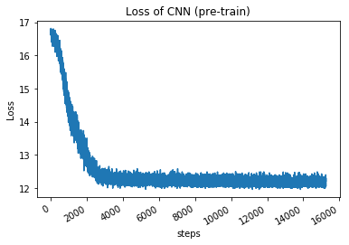

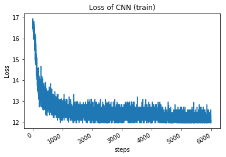

```python
import pandas as pd
import matplotlib.pyplot as plt
csv_file = "./loss/CNN_loss.csv"
CNN_loss = pd.read_csv(csv_file)
CNN_loss.columns
# CNN_loss.head(5)
x = CNN_loss['Unnamed: 0']
y = CNN_loss['loss']
plt.xlabel('steps')
plt.ylabel('Loss')
plt.title('Loss of CNN (pre-train)')
plt.plot(x,y)
# beautify the x-labels
plt.gcf().autofmt_xdate()
plt.show()

csv_file = "./loss/CNN_train_loss.csv"
CNN_loss = pd.read_csv(csv_file)
CNN_loss.columns
# CNN_loss.head(5)
x = CNN_loss['Unnamed: 0']
y = CNN_loss['loss']
plt.xlabel('steps')
plt.ylabel('Loss')
plt.title('Loss of CNN (train)')
plt.plot(x,y)
# beautify the x-labels
plt.gcf().autofmt_xdate()
plt.show()
```

可以看到，兩個階段都有讓Loss逐漸下降至最小的Loss。

#### Model Testing

接下來就用我們200個的Testing dataset來看看我們Model Accuracy如何：

```python
# -*- coding: UTF-8 -*-
import numpy as np
import torch
from torch.autograd import Variable
#from visdom import Visdom # pip install Visdom
import pytorch_dataset
from pytorch_model import CNN

LETTERSTR = "2346789abcdefghjklmnpqrtuxyz"

def main():
    cnn = CNN()
    cnn.eval()
    cnn.load_state_dict(torch.load('./pkl/model_trans.pkl'))
    print("load cnn net.")
    correct_num = 0
    count_c0 = 0
    count_c1 = 0
    count_c2 = 0
    count_c3 = 0
    count_c4 = 0

    step = 0.0
    predict_dataloader = pytorch_dataset.get_predict_data_loader()

    #vis = Visdom()
    for i, (images, labels) in enumerate(predict_dataloader):
        flag = False
        image = images
        vimage = Variable(image)
        out1,out2,out3,out4,out5 = cnn(vimage)
        labels1 = Variable(labels['label1'].float())
        labels2 = Variable(labels['label2'].float())
        labels3 = Variable(labels['label3'].float())
        labels4 = Variable(labels['label4'].float())
        labels5 = Variable(labels['label5'].float())
        l0 = LETTERSTR[torch.max(labels1, 1)[1]]
        l1 = LETTERSTR[torch.max(labels2, 1)[1]]
        l2 = LETTERSTR[torch.max(labels3, 1)[1]]
        l3 = LETTERSTR[torch.max(labels4, 1)[1]]
        l4 = LETTERSTR[torch.max(labels5, 1)[1]]

        c0 = LETTERSTR[torch.max(out1, 1)[1]]
        c1 = LETTERSTR[torch.max(out2, 1)[1]]
        c2 = LETTERSTR[torch.max(out3, 1)[1]]
        c3 = LETTERSTR[torch.max(out4, 1)[1]]
        c4 = LETTERSTR[torch.max(out5, 1)[1]]
        l = '%s%s%s%s%s' % (l0, l1, l2, l3, l4)
        c = '%s%s%s%s%s' % (c0, c1, c2, c3, c4)
        step += 1.0
        correct_num += 1
        count_c0 += 1
        count_c1 += 1
        count_c2 += 1
        count_c3 += 1
        count_c4 += 1

        if l0 != c0 :
            count_c0 -= 1
        if l1 != c1 :
            count_c1 -= 1
        if l2 != c2 :
            count_c2 -= 1
        if l3 != c3 :
            count_c3 -= 1
        if l4 != c4 :
            count_c4 -= 1
        if l0 != c0 or l1 != c1 or l2 != c2 or l3 != c3 or l4 != c4 :
            correct_num -= 1
            flag = True
        if flag :
            print("Wronse answer ! Predict: %s , Truth: %s "%(c,l))
        #vis.images(image, opts=dict(caption=c))
    accuracy = correct_num / step
    accuracy_p0 = count_c0 / step
    accuracy_p1 = count_c1 / step
    accuracy_p2 = count_c2 / step
    accuracy_p3 = count_c3 / step
    accuracy_p4 = count_c4 / step
    print("accuracy = {:.2%} ".format(accuracy))
    print("Position_0 accuracy = {:.2%} ".format(accuracy_p0))
    print("Position_1 accuracy = {:.2%} ".format(accuracy_p1))
    print("Position_2 accuracy = {:.2%} ".format(accuracy_p2))
    print("Position_3 accuracy = {:.2%} ".format(accuracy_p3))
    print("Position_4 accuracy = {:.2%} ".format(accuracy_p4))

if __name__ == '__main__':
    main()
```

```
load cnn net.
Wronse answer ! Predict: m3z3m , Truth: m873m
Wronse answer ! Predict: hdutj , Truth: h8utj
Wronse answer ! Predict: 8rc8g , Truth: 8rz8g
Wronse answer ! Predict: dampx , Truth: damax
Wronse answer ! Predict: 77j6a , Truth: 7cj6a
Wronse answer ! Predict: hnqqu , Truth: hnggu
Wronse answer ! Predict: ja8p2 , Truth: aa8p2
Wronse answer ! Predict: ztctc , Truth: ztetc
Wronse answer ! Predict: gyc4h , Truth: gye44
Wronse answer ! Predict: qpcgq , Truth: qpcgg
Wronse answer ! Predict: arqc3 , Truth: argc3
Wronse answer ! Predict: mhzy4 , Truth: mhzyj
Wronse answer ! Predict: gzr6m , Truth: qzr6m
Wronse answer ! Predict: atzbn , Truth: ftcbn
Wronse answer ! Predict: eht8z , Truth: ehh8z
Wronse answer ! Predict: bucqb , Truth: buegb
Wronse answer ! Predict: 43bne , Truth: 43bme
Wronse answer ! Predict: befca , Truth: byfca
Wronse answer ! Predict: tujcq , Truth: fujcq
Wronse answer ! Predict: xpcqq , Truth: xpcgg
Wronse answer ! Predict: nacxn , Truth: naexn
Wronse answer ! Predict: qe2cq , Truth: ge2cq
Wronse answer ! Predict: qhq7c , Truth: qhg7c
Wronse answer ! Predict: rqm3q , Truth: nqn3a
Wronse answer ! Predict: gd7p2 , Truth: gd7pg
Wronse answer ! Predict: mghgu , Truth: muh8u
Wronse answer ! Predict: xq6zg , Truth: xqqzg
Wronse answer ! Predict: dg6qh , Truth: dg6qb
Wronse answer ! Predict: megne , Truth: mtene
Wronse answer ! Predict: e93nr , Truth: e93m3
Wronse answer ! Predict: gz7hr , Truth: gb7hq
Wronse answer ! Predict: rzbdr , Truth: czbdr
Wronse answer ! Predict: t8fbc , Truth: r8fbc
Wronse answer ! Predict: hmc7z , Truth: hmeyz
Wronse answer ! Predict: 8rtnp , Truth: 8rtmp
Wronse answer ! Predict: mmmxh , Truth: mmmxb
Wronse answer ! Predict: pryb4 , Truth: prybd
Wronse answer ! Predict: 2znne , Truth: 2znme
Wronse answer ! Predict: xdqdn , Truth: bdqdn
```

[output cut: 36 more lines]

```
Wronse answer ! Predict: zffdb , Truth: 7ffdb
Wronse answer ! Predict: qjy8n , Truth: gjy8n
Wronse answer ! Predict: ydduz , Truth: mddrz
Wronse answer ! Predict: c8zh9 , Truth: c8zb9
Wronse answer ! Predict: bgy3a , Truth: hgy3a
Wronse answer ! Predict: qapay , Truth: gapay
Wronse answer ! Predict: bzcuq , Truth: hzeuq
Wronse answer ! Predict: dqhzt , Truth: dgbzt
Wronse answer ! Predict: qbqpa , Truth: qbgpa
accuracy = 58.00%
Position_0 accuracy = 86.00%
Position_1 accuracy = 92.50%
Position_2 accuracy = 88.00%
Position_3 accuracy = 88.50%
Position_4 accuracy = 90.00%
```

#### Accuracy

可以看到：總體Accuracy為58％，五個位置分別為86％、92.5％、88％、88.5％、90％。若每個位置為獨立事件，從總體Accuracy為58％可以推算個別位置應該為89.7％，與得到的結果幾乎相同。

#### 觀察

觀察一些錯誤的驗證碼

[figure not shown]

預測結果分別為qapay、nacxn、qpcgq，從中可以看到(g、q)、(c、e)被預測錯誤  
從前面dataset的觀察，可以歸咎原因，如下

1. 字體顏色變化大
2. 字形多
3. 干擾線存在
4. 背景顏色干擾大

因此除了相似字本身不好判別外，外在因素也大大影響了正確的準確率，就如先前講的ADVERSARIAL ATTACK的概念一般，CV的model很容易會因為一些noisy就對model造成很大的影響。

## Residuial CNN

接著我們想提高Accuracy便開始改變model的架構，並選擇在layer間增加shortcut的residuial CNN，原因如下

1. shortcut能使深層的layer能夠用到淺層layer的feature，能夠減少信息丟失的問題。並且由於淺層是在小細節上的feature，希望能夠藉此增加對字形判斷的精確度。
2. 由於先前的model loss converge在12，因此認為可能是gradient vanishing的問題，因此希望藉由shortcut解決。
3. 藉由shortcut可以更有效的幫助model converge。

### layer 說明

1. ResidualBlock : 連續經過兩個kernel = 3 con2d幾乎等校於經過一個 kenerel = 5的 con2d，使用的parameter數目更少，能夠加速model的計算。因此讓shortcut跨過連續的兩個con2d。
2. layer4的dilated con2d可以在不降低resolution的情況下增加receptive field。此外，藉著shortcut的存在可以使的效果能夠傳遞到較深的layer。

剩下的架構與一般架設CNN無異，主要差別在residuial connection的建立。

```python
# -*- coding: UTF-8 -*-
import torch.nn as nn
import torch
# CNN Model (2 conv layer)
import torch.nn.functional as F

class ResidualBlock(nn.Module):
    def __init__(self, inchannel, outchannel, stride=1):
        super(ResidualBlock, self).__init__()
        self.left = nn.Sequential(
            nn.Conv2d(inchannel, outchannel, kernel_size=3, stride=stride, padding=1),
            nn.BatchNorm2d(outchannel),
            nn.ReLU(),
            nn.Conv2d(outchannel, outchannel, kernel_size=3, stride=1, padding=1),
            nn.BatchNorm2d(outchannel)
        )
        self.shortcut = nn.Sequential(
            nn.Conv2d(inchannel, outchannel, kernel_size=1, stride=stride),
            nn.BatchNorm2d(outchannel)
        )

    def forward(self, x):
        out = self.left(x)
        out += self.shortcut(x)
        out = F.relu(out)
        return out

class RES(nn.Module):
    def __init__(self):
        super(RES, self).__init__()
        self.inchannel = 32
        self.layer1 = nn.Sequential(
            nn.Conv2d(3, 32, kernel_size=3, padding=1),
            nn.ReLU())

        self.layer2 = nn.Sequential(
            self.make_layer(ResidualBlock, 64,  1, stride=1),
            nn.MaxPool2d(2),
            nn.Dropout(0.3))

        self.layer3 = nn.Sequential(
            self.make_layer(ResidualBlock, 64,  1, stride=1),
            nn.MaxPool2d(2),
            nn.Dropout(0.3))

        self.layer4 = nn.Conv2d(64, 64, kernel_size=3, dilation = 2)

        self.layer5 = nn.Sequential(
            self.make_layer(ResidualBlock, 128,  1, stride=1),
            nn.MaxPool2d(2),
            nn.Dropout(0.3))

        self.layer6= nn.Sequential(
            nn.Conv2d(128, 256, kernel_size=3),
            nn.ReLU(),
            nn.BatchNorm2d(256),
            nn.MaxPool2d(2),
            nn.Flatten(),
            nn.Dropout(0.3))
        self.out_layer1 = nn.Sequential(
            nn.Linear(2048,28),
            nn.Softmax(1)
           )
        self.out_layer2 = nn.Sequential(
            nn.Linear(2048,28),
            nn.Softmax(1)
           )
        self.out_layer3 = nn.Sequential(
            nn.Linear(2048,28),
            nn.Softmax(1)
           )
        self.out_layer4 = nn.Sequential(
            nn.Linear(2048,28),
            nn.Softmax(1)
           )
        self.out_layer5 = nn.Sequential(
            nn.Linear(2048,28),
            nn.Softmax(1)
           )

    def make_layer(self, block, channels, num_blocks, stride):
        strides = [stride] + [1] * (num_blocks - 1)   #strides=[1,1]
        layers = []
        for stride in strides:
            layers.append(block(self.inchannel, channels, stride))
            self.inchannel = channels
        return nn.Sequential(*layers)

    def forward(self, x):
        out = self.layer1(x)
        #print(out.size(2),"test2")
        out = self.layer2(out)
        #print(out.size(2),"test2")
        out = self.layer3(out)
        #print(out.size(2),"test3")
        out = self.layer4(out)
        #print(out.size(2),"test4")
        out = self.layer5(out)
        #print(out.size(2),"test5")
        out = self.layer6(out)
        #print(out.size(0),"test6")
        out1 = self.out_layer1(out)
        out2 = self.out_layer2(out)
        out3 = self.out_layer3(out)
        out4 = self.out_layer4(out)
        out5 = self.out_layer5(out)

        return out1,out2,out3,out4,out5
        ##return out

model = RES()
if torch.cuda.is_available():
    model.cuda()

from torchsummary import summary
summary(model, input_size=(3, 60, 160))
```

```
----------------------------------------------------------------
        Layer (type)               Output Shape         Param #
================================================================
            Conv2d-1          [-1, 32, 60, 160]             896
              ReLU-2          [-1, 32, 60, 160]               0
            Conv2d-3          [-1, 64, 60, 160]          18,496
       BatchNorm2d-4          [-1, 64, 60, 160]             128
              ReLU-5          [-1, 64, 60, 160]               0
            Conv2d-6          [-1, 64, 60, 160]          36,928
       BatchNorm2d-7          [-1, 64, 60, 160]             128
            Conv2d-8          [-1, 64, 60, 160]           2,112
       BatchNorm2d-9          [-1, 64, 60, 160]             128
    ResidualBlock-10          [-1, 64, 60, 160]               0
        MaxPool2d-11           [-1, 64, 30, 80]               0
          Dropout-12           [-1, 64, 30, 80]               0
           Conv2d-13           [-1, 64, 30, 80]          36,928
      BatchNorm2d-14           [-1, 64, 30, 80]             128
             ReLU-15           [-1, 64, 30, 80]               0
           Conv2d-16           [-1, 64, 30, 80]          36,928
      BatchNorm2d-17           [-1, 64, 30, 80]             128
           Conv2d-18           [-1, 64, 30, 80]           4,160
      BatchNorm2d-19           [-1, 64, 30, 80]             128
    ResidualBlock-20           [-1, 64, 30, 80]               0
        MaxPool2d-21           [-1, 64, 15, 40]               0
          Dropout-22           [-1, 64, 15, 40]               0
           Conv2d-23           [-1, 64, 11, 36]          36,928
           Conv2d-24          [-1, 128, 11, 36]          73,856
      BatchNorm2d-25          [-1, 128, 11, 36]             256
             ReLU-26          [-1, 128, 11, 36]               0
           Conv2d-27          [-1, 128, 11, 36]         147,584
      BatchNorm2d-28          [-1, 128, 11, 36]             256
           Conv2d-29          [-1, 128, 11, 36]           8,320
      BatchNorm2d-30          [-1, 128, 11, 36]             256
    ResidualBlock-31          [-1, 128, 11, 36]               0
        MaxPool2d-32           [-1, 128, 5, 18]               0
          Dropout-33           [-1, 128, 5, 18]               0
           Conv2d-34           [-1, 256, 3, 16]         295,168
             ReLU-35           [-1, 256, 3, 16]               0
      BatchNorm2d-36           [-1, 256, 3, 16]             512
        MaxPool2d-37            [-1, 256, 1, 8]               0
          Flatten-38                 [-1, 2048]               0
          Dropout-39                 [-1, 2048]               0
           Linear-40                   [-1, 28]          57,372
          Softmax-41                   [-1, 28]               0
           Linear-42                   [-1, 28]          57,372
          Softmax-43                   [-1, 28]               0
           Linear-44                   [-1, 28]          57,372
          Softmax-45                   [-1, 28]               0
           Linear-46                   [-1, 28]          57,372
          Softmax-47                   [-1, 28]               0
           Linear-48                   [-1, 28]          57,372
          Softmax-49                   [-1, 28]               0
================================================================
Total params: 987,212
Trainable params: 987,212
Non-trainable params: 0
----------------------------------------------------------------
Input size (MB): 0.11
Forward/backward pass size (MB): 58.29
Params size (MB): 3.77
Estimated Total Size (MB): 62.16
----------------------------------------------------------------
```

### Training

與CNN model的步驟相同。分為兩個步驟如下，

1. 在生成的70000比驗證馬上進行pretrain。
2. FINETUNING到蒐集下來的目標網站驗證碼1000筆。

#### pretrain的理由

即使兩個驗證碼的圖形差異有些大，但是作為general的信息仍然是共通的，例如：偵測數字位置、辨別字、處理旋轉、顏色變化等。因此用能夠大量取得的自主生成的驗證碼讓model先掌握基礎能力，再藉由FINETUNING做細部調整。

兩步驟選用的hyperparameters、batch_size等與CNN model相同。

```python
# -*- coding: UTF-8 -*-
import torch
import torch.nn as nn
from torch.autograd import Variable
import pytorch_dataset
from ResModel import RES
import pandas as pd

# Hyper Parameters
num_epochs = 70
learning_rate = 0.001
use_cuda=True
def main():
    losses = []
    device = torch.device("cuda" if (use_cuda and torch.cuda.is_available()) else "cpu")
    res = RES().to(device)
    res.train()

    #res.load_state_dict(torch.load('res_model.pkl'))

    print('init net')
    criterion = nn.CrossEntropyLoss()
    optimizer = torch.optim.Adam(res.parameters(), lr=learning_rate)


    train_dataloader = pytorch_dataset.get_train_data_loader()
    for epoch in range(num_epochs):
        for i, (images, labels) in enumerate(train_dataloader):
            images = Variable(images).to(device)
            labels1 = Variable(labels['label1'].float()).to(device)
            labels2 = Variable(labels['label2'].float()).to(device)
            labels3 = Variable(labels['label3'].float()).to(device)
            labels4 = Variable(labels['label4'].float()).to(device)
            labels5 = Variable(labels['label5'].float()).to(device)
            out1,out2,out3,out4, out5 = res(images)
            #out = res(images)

            # print(predict_labels.type)
            # print(labels.type)
            loss1 = criterion(out1, torch.max(labels1, 1)[1])
            loss2 = criterion(out2, torch.max(labels2, 1)[1])
            loss3 = criterion(out3, torch.max(labels3, 1)[1])
            loss4 = criterion(out4, torch.max(labels4, 1)[1])
            loss5 = criterion(out5, torch.max(labels5, 1)[1])
            loss = (loss1+loss2+loss3+loss4+loss5)
            optimizer.zero_grad()
            loss.backward()
            optimizer.step()
            if (i+1) % 10 == 0:
                print("epoch:", epoch, "step:", i, "loss:", loss.item())
                losses.append(loss.item())
            if (i+1) % 100 == 0:
                torch.save(res.state_dict(), "./pkl/res_model.pkl")   #current is model.pkl
                print("save model")

        print("epoch:", epoch, "step:", i, "loss:", loss.item())
    torch.save(res.state_dict(), "./pkl/res_model.pkl")   #current is model.pkl
    print("save last model")

    df = pd.DataFrame(losses, columns = ["loss"])
    df.to_csv('./loss/Res_loss.csv')

if __name__ == '__main__':
    main()
```

```
init net
epoch: 0 step: 9 loss: 16.677560806274414
epoch: 0 step: 19 loss: 16.670425415039062
epoch: 0 step: 29 loss: 16.68500518798828
epoch: 0 step: 39 loss: 16.72053337097168
epoch: 0 step: 49 loss: 16.66716194152832
epoch: 0 step: 59 loss: 16.728307723999023
epoch: 0 step: 69 loss: 16.698036193847656
epoch: 0 step: 79 loss: 16.653348922729492
epoch: 0 step: 89 loss: 16.798744201660156
epoch: 0 step: 99 loss: 16.818500518798828
save model
epoch: 0 step: 109 loss: 16.56524658203125
epoch: 0 step: 119 loss: 16.64486312866211
epoch: 0 step: 129 loss: 16.648218154907227
epoch: 0 step: 139 loss: 16.645963668823242
epoch: 0 step: 149 loss: 16.709213256835938
epoch: 0 step: 159 loss: 16.5578556060791
epoch: 0 step: 169 loss: 16.727506637573242
epoch: 0 step: 179 loss: 16.66754150390625
epoch: 0 step: 189 loss: 16.658769607543945
epoch: 0 step: 199 loss: 16.64649200439453
save model
epoch: 0 step: 209 loss: 16.6679630279541
epoch: 0 step: 219 loss: 16.648208618164062
epoch: 0 step: 229 loss: 16.59072494506836
epoch: 0 step: 239 loss: 16.702983856201172
epoch: 0 step: 249 loss: 16.773988723754883
epoch: 0 step: 259 loss: 16.537548065185547
epoch: 0 step: 269 loss: 16.55091667175293
epoch: 0 step: 279 loss: 16.407623291015625
epoch: 0 step: 289 loss: 16.735687255859375
epoch: 0 step: 299 loss: 16.59926986694336
save model
epoch: 0 step: 309 loss: 16.548139572143555
epoch: 0 step: 319 loss: 16.58539581298828
epoch: 0 step: 329 loss: 16.453662872314453
epoch: 0 step: 339 loss: 16.654939651489258
epoch: 0 step: 349 loss: 16.71174430847168
epoch: 0 step: 359 loss: 16.626760482788086
```

[output cut: 16747 more lines]

```
epoch: 69 step: 2069 loss: 12.23948860168457
epoch: 69 step: 2079 loss: 12.177165985107422
epoch: 69 step: 2089 loss: 12.114813804626465
epoch: 69 step: 2099 loss: 12.082134246826172
save model
epoch: 69 step: 2109 loss: 12.206783294677734
epoch: 69 step: 2119 loss: 12.23948860168457
epoch: 69 step: 2129 loss: 12.146042823791504
epoch: 69 step: 2139 loss: 12.052550315856934
epoch: 69 step: 2149 loss: 12.083318710327148
epoch: 69 step: 2159 loss: 12.083648681640625
epoch: 69 step: 2169 loss: 12.146285057067871
epoch: 69 step: 2179 loss: 12.063108444213867
epoch: 69 step: 2187 loss: 12.101665496826172
save last model
```

```python
import torch
import torch.nn as nn
from torch.autograd import Variable
import pytorch_dataset
from ResModel import RES

import pandas

# Hyper Parameters
num_epochs = 500
learning_rate = 0.001
use_cuda=True


def main():

    device = torch.device("cuda" if (use_cuda and torch.cuda.is_available()) else "cpu")
    losses = []
    res = RES().to(device)
    res.train()
    res.load_state_dict(torch.load('./pkl/res_model.pkl'))
    print('init net')
    criterion = nn.CrossEntropyLoss()
    optimizer = torch.optim.Adam(res.parameters(), lr=learning_rate)

    lr_scheduler = torch.optim.lr_scheduler.StepLR(optimizer,
                                                   step_size=100,
                                                   gamma=0.5)

    # Train the Model
    train_dataloader = pytorch_dataset.get_transfer_data_loader()
    for epoch in range(num_epochs):
        for i, (images, labels) in enumerate(train_dataloader):
            images = Variable(images).to(device)
            labels1 = Variable(labels['label1'].float()).to(device)
            labels2 = Variable(labels['label2'].float()).to(device)
            labels3 = Variable(labels['label3'].float()).to(device)
            labels4 = Variable(labels['label4'].float()).to(device)
            labels5 = Variable(labels['label5'].float()).to(device)
            out1,out2,out3,out4, out5 = res(images)
            #out = res(images)

            # print(predict_labels.type)
            # print(labels.type)
            loss1 = criterion(out1, torch.max(labels1, 1)[1])
            loss2 = criterion(out2, torch.max(labels2, 1)[1])
            loss3 = criterion(out3, torch.max(labels3, 1)[1])
            loss4 = criterion(out4, torch.max(labels4, 1)[1])
            loss5 = criterion(out5, torch.max(labels5, 1)[1])
            loss = (loss1+loss2+loss3+loss4+loss5)
            optimizer.zero_grad()
            loss.backward()
            optimizer.step()
            if (i+1) % 10 == 0:
                print("epoch:", epoch, "step:", i, "loss:", loss.item())
                losses.append(loss.item())
            if (i+1) % 100 == 0:
                torch.save(res.state_dict(), "./pkl/res_trans.pkl")   #current is model.pkl
                print("save model")

        print("epoch:", epoch, "step:", i, "loss:", loss.item())
        lr_scheduler.step()
    torch.save(res.state_dict(), "./pkl/res_trans.pkl")   #current is model.pkl
    print("save last model")

    df = pd.DataFrame(losses, columns = ["loss"])
    df.to_csv('./loss/Res_trans_loss.csv')

if __name__ == '__main__':
    main()
```

```
init net
epoch: 0 step: 9 loss: 16.747188568115234
epoch: 0 step: 19 loss: 16.44676971435547
epoch: 0 step: 29 loss: 16.206127166748047
epoch: 0 step: 39 loss: 16.45452880859375
epoch: 0 step: 49 loss: 16.69969367980957
epoch: 0 step: 59 loss: 16.825471878051758
epoch: 0 step: 69 loss: 16.529178619384766
epoch: 0 step: 79 loss: 16.453685760498047
epoch: 0 step: 89 loss: 16.57221031188965
epoch: 0 step: 99 loss: 16.55718994140625
save model
epoch: 0 step: 109 loss: 15.955887794494629
epoch: 0 step: 119 loss: 16.574087142944336
epoch: 0 step: 124 loss: 16.518476486206055
epoch: 1 step: 9 loss: 16.45024871826172
epoch: 1 step: 19 loss: 16.20401954650879
epoch: 1 step: 29 loss: 16.205568313598633
epoch: 1 step: 39 loss: 16.207958221435547
epoch: 1 step: 49 loss: 16.081741333007812
epoch: 1 step: 59 loss: 16.33024787902832
epoch: 1 step: 69 loss: 16.2833309173584
epoch: 1 step: 79 loss: 16.45517921447754
epoch: 1 step: 89 loss: 16.501934051513672
epoch: 1 step: 99 loss: 16.43865394592285
save model
epoch: 1 step: 109 loss: 16.436784744262695
epoch: 1 step: 119 loss: 16.169252395629883
epoch: 1 step: 124 loss: 16.527177810668945
epoch: 2 step: 9 loss: 16.45553970336914
epoch: 2 step: 19 loss: 15.295177459716797
epoch: 2 step: 29 loss: 15.829899787902832
epoch: 2 step: 39 loss: 16.32097816467285
epoch: 2 step: 49 loss: 16.435192108154297
epoch: 2 step: 59 loss: 15.953956604003906
epoch: 2 step: 69 loss: 15.612065315246582
epoch: 2 step: 79 loss: 16.07827377319336
epoch: 2 step: 89 loss: 16.068893432617188
epoch: 2 step: 99 loss: 16.319984436035156
save model
```

[output cut: 6947 more lines]

```
epoch: 499 step: 9 loss: 12.583518981933594
epoch: 499 step: 19 loss: 12.083812713623047
epoch: 499 step: 29 loss: 12.207808494567871
epoch: 499 step: 39 loss: 11.958812713623047
epoch: 499 step: 49 loss: 12.083812713623047
epoch: 499 step: 59 loss: 12.209575653076172
epoch: 499 step: 69 loss: 12.333812713623047
epoch: 499 step: 79 loss: 12.208807945251465
epoch: 499 step: 89 loss: 12.083812713623047
epoch: 499 step: 99 loss: 11.958812713623047
save model
epoch: 499 step: 109 loss: 12.333749771118164
epoch: 499 step: 119 loss: 12.083812713623047
epoch: 499 step: 124 loss: 12.244526863098145
save last model
```

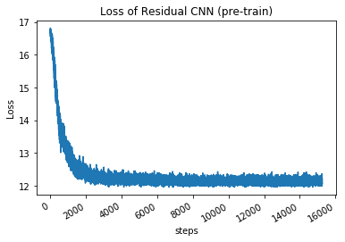

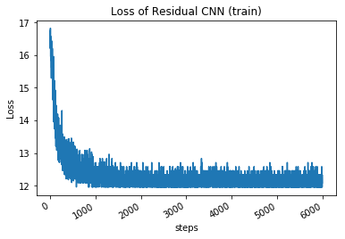

```python
import pandas as pd
import matplotlib.pyplot as plt
csv_file = "./loss/Res_loss.csv"
CNN_loss = pd.read_csv(csv_file)
CNN_loss.columns
# CNN_loss.head(5)
x = CNN_loss['Unnamed: 0']
y = CNN_loss['loss']
plt.xlabel('steps')
plt.ylabel('Loss')
plt.title('Loss of Residual CNN (pre-train)')
plt.plot(x,y)
# beautify the x-labels
plt.gcf().autofmt_xdate()
plt.show()

csv_file = "./loss/Res_trans_loss.csv"
CNN_loss = pd.read_csv(csv_file)
CNN_loss.columns
# CNN_loss.head(5)
x = CNN_loss['Unnamed: 0']
y = CNN_loss['loss']
plt.xlabel('steps')
plt.ylabel('Loss')
plt.title('Loss of Residual CNN (train)')
plt.plot(x,y)
# beautify the x-labels
plt.gcf().autofmt_xdate()
plt.show()
```

可以看到，兩次training都有讓Loss逐漸變小。  
此外，將兩圖與CNN model做比較，可以看出R-CNN的loss震盪幅度較小，比較穩定收斂在一個範圍內。  
Train好了之後來丟入我們的Test dataset看看Accuracy

```python
# -*- coding: UTF-8 -*-
import numpy as np
import torch
from torch.autograd import Variable
#from visdom import Visdom # pip install Visdom
import pytorch_dataset
from ResModel import RES

LETTERSTR = "2346789abcdefghjklmnpqrtuxyz"

def main():
    res = RES()
    res.eval()
    res.load_state_dict(torch.load('./pkl/res_trans.pkl'))
    print("load cnn net.")
    correct_num = 0
    count_c0 = 0
    count_c1 = 0
    count_c2 = 0
    count_c3 = 0
    count_c4 = 0
    step = 0.0
    predict_dataloader = pytorch_dataset.get_predict_data_loader()

    #vis = Visdom()
    for i, (images, labels) in enumerate(predict_dataloader):
        flag = False
        image = images
        vimage = Variable(image)
        out1,out2,out3,out4,out5 = res(vimage)
        labels1 = Variable(labels['label1'].float())
        labels2 = Variable(labels['label2'].float())
        labels3 = Variable(labels['label3'].float())
        labels4 = Variable(labels['label4'].float())
        labels5 = Variable(labels['label5'].float())
        l0 = LETTERSTR[torch.max(labels1, 1)[1]]
        l1 = LETTERSTR[torch.max(labels2, 1)[1]]
        l2 = LETTERSTR[torch.max(labels3, 1)[1]]
        l3 = LETTERSTR[torch.max(labels4, 1)[1]]
        l4 = LETTERSTR[torch.max(labels5, 1)[1]]

        c0 = LETTERSTR[torch.max(out1, 1)[1]]
        c1 = LETTERSTR[torch.max(out2, 1)[1]]
        c2 = LETTERSTR[torch.max(out3, 1)[1]]
        c3 = LETTERSTR[torch.max(out4, 1)[1]]
        c4 = LETTERSTR[torch.max(out5, 1)[1]]
        l = '%s%s%s%s%s' % (l0, l1, l2, l3, l4)
        c = '%s%s%s%s%s' % (c0, c1, c2, c3, c4)
        step += 1.0
        correct_num += 1
        count_c0 += 1
        count_c1 += 1
        count_c2 += 1
        count_c3 += 1
        count_c4 += 1

        if l0 != c0 :
            count_c0 -= 1
        if l1 != c1 :
            count_c1 -= 1
        if l2 != c2 :
            count_c2 -= 1
        if l3 != c3 :
            count_c3 -= 1
        if l4 != c4 :
            count_c4 -= 1

        if l0 != c0 or l1 != c1 or l2 != c2 or l3 != c3 or l4 != c4 :
            correct_num -= 1
            flag = True
        if flag :
            print("Wronse answer ! Predict: %s , Truth: %s "%(c,l))
        #vis.images(image, opts=dict(caption=c))
    accuracy = correct_num / step
    accuracy_p0 = count_c0 / step
    accuracy_p1 = count_c1 / step
    accuracy_p2 = count_c2 / step
    accuracy_p3 = count_c3 / step
    accuracy_p4 = count_c4 / step
    print("accuracy = {:.2%} ".format(accuracy))
    print("Position_0 accuracy = {:.2%} ".format(accuracy_p0))
    print("Position_1 accuracy = {:.2%} ".format(accuracy_p1))
    print("Position_2 accuracy = {:.2%} ".format(accuracy_p2))
    print("Position_3 accuracy = {:.2%} ".format(accuracy_p3))
    print("Position_4 accuracy = {:.2%} ".format(accuracy_p4))

if __name__ == '__main__':
    main()
```

```
load cnn net.
Wronse answer ! Predict: qgunt , Truth: q2unt
Wronse answer ! Predict: n6g2g , Truth: m6g2g
Wronse answer ! Predict: yddbz , Truth: mddrz
Wronse answer ! Predict: a9ft6 , Truth: ayft6
Wronse answer ! Predict: bzmr4 , Truth: bymr4
Wronse answer ! Predict: azzqg , Truth: a2zqg
Wronse answer ! Predict: ced7y , Truth: cedzy
Wronse answer ! Predict: azncq , Truth: auncq
Wronse answer ! Predict: 488by , Truth: 4y8bz
Wronse answer ! Predict: pmtdc , Truth: qmtdc
Wronse answer ! Predict: rez7h , Truth: cazzh
Wronse answer ! Predict: mzytq , Truth: m2ytq
Wronse answer ! Predict: tqtnr , Truth: tqtnn
Wronse answer ! Predict: mmmxy , Truth: mmmxb
Wronse answer ! Predict: ehu8z , Truth: ehh8z
Wronse answer ! Predict: dgbat , Truth: dgbzt
Wronse answer ! Predict: b4m3g , Truth: b4mzg
Wronse answer ! Predict: 7jj6a , Truth: 7cj6a
Wronse answer ! Predict: ea8p2 , Truth: aa8p2
Wronse answer ! Predict: xqqag , Truth: xqqzg
Wronse answer ! Predict: btfca , Truth: byfca
Wronse answer ! Predict: pqh36 , Truth: pqhz6
Wronse answer ! Predict: gle44 , Truth: gye44
Wronse answer ! Predict: mu3mj , Truth: m43mj
Wronse answer ! Predict: xfncp , Truth: xyncp
Wronse answer ! Predict: e93mn , Truth: e93m3
Wronse answer ! Predict: grfah , Truth: grfzh
Wronse answer ! Predict: 8rp8g , Truth: 8rz8g
Wronse answer ! Predict: mzh8u , Truth: muh8u
Wronse answer ! Predict: 4hmqy , Truth: xhmqy
Wronse answer ! Predict: rtnbn , Truth: ftcbn
Wronse answer ! Predict: glzxp , Truth: g2zxp
Wronse answer ! Predict: hn3ad , Truth: hn3zd
Wronse answer ! Predict: ymdap , Truth: ymdzp
Wronse answer ! Predict: mhtyr , Truth: mhthr
Wronse answer ! Predict: cfqe6 , Truth: ctqe6
Wronse answer ! Predict: q3ghe , Truth: qyghe
Wronse answer ! Predict: tnpa6 , Truth: tnpad
accuracy = 81.00%
Position_0 accuracy = 96.50%
Position_1 accuracy = 91.50%
Position_2 accuracy = 98.50%
Position_3 accuracy = 94.50%
Position_4 accuracy = 97.50%
```

可以看出來Accuracy明顯大幅增加，來到81％的答對率，五個位置分別為96.5％、91.50％、、98.50％、、94.50％、、97.50％、，比只用CNN的module還要高上許多。  
因為運用Residual Block能夠將淺層的Feature回傳給深層，因此較少Feature Loss的情況，因此才能更能辨識出隱藏在每一層裡的Feature。

##### 小結論：Residual CNN 比 單純 CNN 好上許多 （81％ vs 58%）

但這時我們又想到：我們是假設在先用大量資料train的情況下，再用少量的特殊資料來customize我們的Module適應我們所要解決的問題，像是許多人train CNN前都會先將VGG/ResNet等dataset先train一次。  
若事實並非如此呢？如果直接用我們少量但是是符合我們狀況（ie. 我們網站的驗證圖，而非為了臺鐵網站genarate出的驗證圖）的data來train，會不會達到更好的狀況？

## CNN & RES module with only Customized dataset.

因此這次我們只用我們的1000筆目標網站的驗證碼來train，探討看看會不會有更好的效果。  
首先是CNN module：

```python
import torch
import torch.nn as nn
from torch.autograd import Variable
import pytorch_dataset
from pytorch_model import CNN
import pandas as pd

# Hyper Parameters
num_epochs = 500
learning_rate = 0.001
use_cuda=True

def main():
    losses=[]
    device = torch.device("cuda" if (use_cuda and torch.cuda.is_available()) else "cpu")
    cnn = CNN().to(device)
    cnn.train()
    #cnn.load_state_dict(torch.load('model.pkl'))
    print('init net')
    criterion = nn.CrossEntropyLoss()
    optimizer = torch.optim.Adam(cnn.parameters(), lr=learning_rate)
    lr_scheduler = torch.optim.lr_scheduler.StepLR(optimizer,
    step_size=100,
    gamma=0.5)
    # Train the Model
    train_dataloader = pytorch_dataset.get_transfer_data_loader()
    for epoch in range(num_epochs):
        for i, (images, labels) in enumerate(train_dataloader):
            images = Variable(images).to(device)
            labels1 = Variable(labels['label1'].float()).to(device)
            labels2 = Variable(labels['label2'].float()).to(device)
            labels3 = Variable(labels['label3'].float()).to(device)
            labels4 = Variable(labels['label4'].float()).to(device)
            labels5 = Variable(labels['label5'].float()).to(device)
            out1,out2,out3,out4, out5 = cnn(images)
            #out = cnn(images)

            # print(predict_labels.type)
            # print(labels.type)
            loss1 = criterion(out1, torch.max(labels1, 1)[1])
            loss2 = criterion(out2, torch.max(labels2, 1)[1])
            loss3 = criterion(out3, torch.max(labels3, 1)[1])
            loss4 = criterion(out4, torch.max(labels4, 1)[1])
            loss5 = criterion(out5, torch.max(labels5, 1)[1])
            loss = (loss1+loss2+loss3+loss4+loss5)
            optimizer.zero_grad()
            loss.backward()
            optimizer.step()
            if (i+1) % 10 == 0:
                print("epoch:", epoch, "step:", i, "loss:", loss.item())
                losses.append( loss.item())
            if (i+1) % 100 == 0:
                torch.save(cnn.state_dict(), "./pkl/cnn_direct.pkl")   #current is model.pkl
                print("save model")
        print("epoch:", epoch, "step:", i, "loss:", loss.item())
        optimizer.step()
    torch.save(cnn.state_dict(), "./pkl/cnn_direct.pkl")   #current is model.pkl
    print("save last model")
    df = pd.DataFrame(losses, columns = ["loss"])
    df.to_csv('./loss/CNN_direct_loss.csv')

if __name__ == '__main__':
    main()
```

```
init net
epoch: 0 step: 9 loss: 16.787952423095703
epoch: 0 step: 19 loss: 16.6395263671875
epoch: 0 step: 29 loss: 16.58837127685547
epoch: 0 step: 39 loss: 16.673309326171875
epoch: 0 step: 49 loss: 16.611467361450195
epoch: 0 step: 59 loss: 16.59438705444336
epoch: 0 step: 69 loss: 16.41672134399414
epoch: 0 step: 79 loss: 16.602197647094727
epoch: 0 step: 89 loss: 16.375469207763672
epoch: 0 step: 99 loss: 16.640817642211914
save model
epoch: 0 step: 109 loss: 16.359506607055664
epoch: 0 step: 119 loss: 16.7054443359375
epoch: 0 step: 124 loss: 16.39285659790039
epoch: 1 step: 9 loss: 16.499921798706055
epoch: 1 step: 19 loss: 16.291275024414062
epoch: 1 step: 29 loss: 16.376785278320312
epoch: 1 step: 39 loss: 16.409225463867188
epoch: 1 step: 49 loss: 16.51996421813965
epoch: 1 step: 59 loss: 16.156396865844727
epoch: 1 step: 69 loss: 16.40085220336914
epoch: 1 step: 79 loss: 16.26897621154785
epoch: 1 step: 89 loss: 16.021129608154297
epoch: 1 step: 99 loss: 16.265182495117188
save model
epoch: 1 step: 109 loss: 15.99098014831543
epoch: 1 step: 119 loss: 15.880228996276855
epoch: 1 step: 124 loss: 16.235082626342773
epoch: 2 step: 9 loss: 16.248992919921875
epoch: 2 step: 19 loss: 16.812950134277344
epoch: 2 step: 29 loss: 16.08599853515625
epoch: 2 step: 39 loss: 15.62553596496582
epoch: 2 step: 49 loss: 16.256994247436523
epoch: 2 step: 59 loss: 15.66341781616211
epoch: 2 step: 69 loss: 16.35697364807129
epoch: 2 step: 79 loss: 15.641898155212402
epoch: 2 step: 89 loss: 15.676377296447754
epoch: 2 step: 99 loss: 15.174469947814941
save model
```

[output cut: 6947 more lines]

```
epoch: 499 step: 9 loss: 12.208812713623047
epoch: 499 step: 19 loss: 11.958812713623047
epoch: 499 step: 29 loss: 11.958813667297363
epoch: 499 step: 39 loss: 11.958812713623047
epoch: 499 step: 49 loss: 12.083812713623047
epoch: 499 step: 59 loss: 11.958813667297363
epoch: 499 step: 69 loss: 12.347587585449219
epoch: 499 step: 79 loss: 11.958831787109375
epoch: 499 step: 89 loss: 11.958812713623047
epoch: 499 step: 99 loss: 11.958812713623047
save model
epoch: 499 step: 109 loss: 12.083812713623047
epoch: 499 step: 119 loss: 11.958812713623047
epoch: 499 step: 124 loss: 11.963111877441406
save last model
```

```python
import torch
import torch.nn as nn
from torch.autograd import Variable
import pytorch_dataset
from ResModel import RES

import pandas

# Hyper Parameters
num_epochs = 500
learning_rate = 0.001
use_cuda=True


def main():

    device = torch.device("cuda" if (use_cuda and torch.cuda.is_available()) else "cpu")
    losses = []
    res = RES().to(device)
    res.train()
#    res.load_state_dict(torch.load('res_model.pkl'))
    print('init net')
    criterion = nn.CrossEntropyLoss()
    optimizer = torch.optim.Adam(res.parameters(), lr=learning_rate)

    lr_scheduler = torch.optim.lr_scheduler.StepLR(optimizer,
                                                   step_size=100,
                                                   gamma=0.5)

    # Train the Model
    train_dataloader = pytorch_dataset.get_transfer_data_loader()
    for epoch in range(num_epochs):
        for i, (images, labels) in enumerate(train_dataloader):
            images = Variable(images).to(device)
            labels1 = Variable(labels['label1'].float()).to(device)
            labels2 = Variable(labels['label2'].float()).to(device)
            labels3 = Variable(labels['label3'].float()).to(device)
            labels4 = Variable(labels['label4'].float()).to(device)
            labels5 = Variable(labels['label5'].float()).to(device)
            out1,out2,out3,out4, out5 = res(images)
            #out = res(images)

            # print(predict_labels.type)
            # print(labels.type)
            loss1 = criterion(out1, torch.max(labels1, 1)[1])
            loss2 = criterion(out2, torch.max(labels2, 1)[1])
            loss3 = criterion(out3, torch.max(labels3, 1)[1])
            loss4 = criterion(out4, torch.max(labels4, 1)[1])
            loss5 = criterion(out5, torch.max(labels5, 1)[1])
            loss = (loss1+loss2+loss3+loss4+loss5)
            optimizer.zero_grad()
            loss.backward()
            optimizer.step()
            if (i+1) % 10 == 0:
                print("epoch:", epoch, "step:", i, "loss:", loss.item())
                losses.append(loss.item())
            if (i+1) % 100 == 0:
                torch.save(res.state_dict(), "./pkl/res_direct.pkl")   #current is model.pkl
                print("save model")

        print("epoch:", epoch, "step:", i, "loss:", loss.item())
        lr_scheduler.step()
    torch.save(res.state_dict(), "./pkl/res_direct.pkl")   #current is model.pkl
    print("save last model")

    df = pd.DataFrame(losses, columns = ["loss"])
    df.to_csv('Res_direct_loss.csv')

if __name__ == '__main__':
    main()
```

```
init net
epoch: 0 step: 9 loss: 16.598251342773438
epoch: 0 step: 19 loss: 16.522287368774414
epoch: 0 step: 29 loss: 16.642040252685547
epoch: 0 step: 39 loss: 16.62972640991211
epoch: 0 step: 49 loss: 16.760326385498047
epoch: 0 step: 59 loss: 16.77560043334961
epoch: 0 step: 69 loss: 16.65980339050293
epoch: 0 step: 79 loss: 16.58844566345215
epoch: 0 step: 89 loss: 16.698410034179688
epoch: 0 step: 99 loss: 16.593730926513672
save model
epoch: 0 step: 109 loss: 16.483745574951172
epoch: 0 step: 119 loss: 16.678707122802734
epoch: 0 step: 124 loss: 16.74277687072754
epoch: 1 step: 9 loss: 16.643474578857422
epoch: 1 step: 19 loss: 16.68824577331543
epoch: 1 step: 29 loss: 16.661556243896484
epoch: 1 step: 39 loss: 16.192947387695312
epoch: 1 step: 49 loss: 16.30733299255371
epoch: 1 step: 59 loss: 16.722179412841797
epoch: 1 step: 69 loss: 16.623079299926758
epoch: 1 step: 79 loss: 16.369550704956055
epoch: 1 step: 89 loss: 16.257890701293945
epoch: 1 step: 99 loss: 16.013975143432617
save model
epoch: 1 step: 109 loss: 16.599308013916016
epoch: 1 step: 119 loss: 16.22711753845215
epoch: 1 step: 124 loss: 16.357852935791016
epoch: 2 step: 9 loss: 15.880084991455078
epoch: 2 step: 19 loss: 15.591642379760742
epoch: 2 step: 29 loss: 15.47724437713623
epoch: 2 step: 39 loss: 15.887099266052246
epoch: 2 step: 49 loss: 15.792560577392578
epoch: 2 step: 59 loss: 15.90754508972168
epoch: 2 step: 69 loss: 16.194320678710938
epoch: 2 step: 79 loss: 16.21681022644043
epoch: 2 step: 89 loss: 16.147932052612305
epoch: 2 step: 99 loss: 16.172176361083984
save model
```

[output cut: 6947 more lines]

```
epoch: 499 step: 9 loss: 11.958858489990234
epoch: 499 step: 19 loss: 11.958812713623047
epoch: 499 step: 29 loss: 11.958812713623047
epoch: 499 step: 39 loss: 11.958813667297363
epoch: 499 step: 49 loss: 11.958818435668945
epoch: 499 step: 59 loss: 11.958812713623047
epoch: 499 step: 69 loss: 11.958812713623047
epoch: 499 step: 79 loss: 11.958812713623047
epoch: 499 step: 89 loss: 11.958812713623047
epoch: 499 step: 99 loss: 11.958812713623047
save model
epoch: 499 step: 109 loss: 11.958812713623047
epoch: 499 step: 119 loss: 11.958812713623047
epoch: 499 step: 124 loss: 11.958812713623047
save last model
```

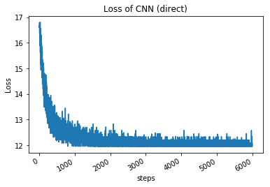

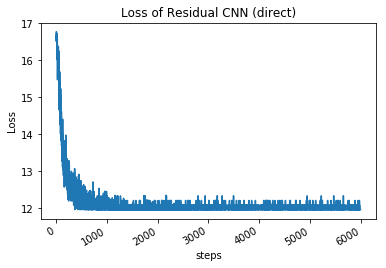

```python
import pandas as pd
import matplotlib.pyplot as plt
csv_file = "./loss/CNN_direct_loss.csv"
CNN_loss = pd.read_csv(csv_file)
CNN_loss.columns
# CNN_loss.head(5)
x = CNN_loss['Unnamed: 0']
y = CNN_loss['loss']
plt.xlabel('steps')
plt.ylabel('Loss')
plt.title('Loss of CNN (direct)')
plt.plot(x,y)
# beautify the x-labels
plt.gcf().autofmt_xdate()
plt.show()

csv_file = "./loss/Res_direct_loss.csv"
CNN_loss = pd.read_csv(csv_file)
CNN_loss.columns
# CNN_loss.head(5)
x = CNN_loss['Unnamed: 0']
y = CNN_loss['loss']
plt.xlabel('steps')
plt.ylabel('Loss')
plt.title('Loss of Residual CNN (direct)')
plt.plot(x,y)
# beautify the x-labels
plt.gcf().autofmt_xdate()
plt.show()
```

```python
# -*- coding: UTF-8 -*-
import numpy as np
import torch
from torch.autograd import Variable
#from visdom import Visdom # pip install Visdom
import pytorch_dataset
from pytorch_model import CNN

LETTERSTR = "2346789abcdefghjklmnpqrtuxyz"

def main():
    cnn = CNN()
    cnn.eval()
    cnn.load_state_dict(torch.load('./pkl/cnn_direct.pkl'))
    print("load cnn net.")
    correct_num = 0
    count_c0 = 0
    count_c1 = 0
    count_c2 = 0
    count_c3 = 0
    count_c4 = 0

    step = 0.0
    predict_dataloader = pytorch_dataset.get_predict_data_loader()

    #vis = Visdom()
    for i, (images, labels) in enumerate(predict_dataloader):
        flag = False
        image = images
        vimage = Variable(image)
        out1,out2,out3,out4,out5 = cnn(vimage)
        labels1 = Variable(labels['label1'].float())
        labels2 = Variable(labels['label2'].float())
        labels3 = Variable(labels['label3'].float())
        labels4 = Variable(labels['label4'].float())
        labels5 = Variable(labels['label5'].float())
        l0 = LETTERSTR[torch.max(labels1, 1)[1]]
        l1 = LETTERSTR[torch.max(labels2, 1)[1]]
        l2 = LETTERSTR[torch.max(labels3, 1)[1]]
        l3 = LETTERSTR[torch.max(labels4, 1)[1]]
        l4 = LETTERSTR[torch.max(labels5, 1)[1]]

        c0 = LETTERSTR[torch.max(out1, 1)[1]]
        c1 = LETTERSTR[torch.max(out2, 1)[1]]
        c2 = LETTERSTR[torch.max(out3, 1)[1]]
        c3 = LETTERSTR[torch.max(out4, 1)[1]]
        c4 = LETTERSTR[torch.max(out5, 1)[1]]
        l = '%s%s%s%s%s' % (l0, l1, l2, l3, l4)
        c = '%s%s%s%s%s' % (c0, c1, c2, c3, c4)
        step += 1.0
        correct_num += 1
        count_c0 += 1
        count_c1 += 1
        count_c2 += 1
        count_c3 += 1
        count_c4 += 1

        if l0 != c0 :
            count_c0 -= 1
        if l1 != c1 :
            count_c1 -= 1
        if l2 != c2 :
            count_c2 -= 1
        if l3 != c3 :
            count_c3 -= 1
        if l4 != c4 :
            count_c4 -= 1
        if l0 != c0 or l1 != c1 or l2 != c2 or l3 != c3 or l4 != c4 :
            correct_num -= 1
            flag = True
        if flag :
            print("Wronse answer ! Predict: %s , Truth: %s "%(c,l))
        #vis.images(image, opts=dict(caption=c))
    accuracy = correct_num / step
    accuracy_p0 = count_c0 / step
    accuracy_p1 = count_c1 / step
    accuracy_p2 = count_c2 / step
    accuracy_p3 = count_c3 / step
    accuracy_p4 = count_c4 / step
    print("accuracy = {:.2%} ".format(accuracy))
    print("Position_0 accuracy = {:.2%} ".format(accuracy_p0))
    print("Position_1 accuracy = {:.2%} ".format(accuracy_p1))
    print("Position_2 accuracy = {:.2%} ".format(accuracy_p2))
    print("Position_3 accuracy = {:.2%} ".format(accuracy_p3))
    print("Position_4 accuracy = {:.2%} ".format(accuracy_p4))

if __name__ == '__main__':
    main()
```

```
load cnn net.
Wronse answer ! Predict: byfcq , Truth: byfca
Wronse answer ! Predict: mrc7c , Truth: m3c7c
Wronse answer ! Predict: mmmxh , Truth: mmmxb
Wronse answer ! Predict: bzeug , Truth: hzeuq
Wronse answer ! Predict: 9brbm , Truth: 9hrhm
Wronse answer ! Predict: xbmqu , Truth: xhmqy
Wronse answer ! Predict: mtu33 , Truth: mtua3
Wronse answer ! Predict: nb4fn , Truth: nhdfn
Wronse answer ! Predict: g8n6r , Truth: ggn6r
Wronse answer ! Predict: mu3mx , Truth: m43mj
Wronse answer ! Predict: agu3n , Truth: 2gu3n
Wronse answer ! Predict: fq2gd , Truth: rq2qd
Wronse answer ! Predict: r8zh9 , Truth: c8zb9
Wronse answer ! Predict: dg6qh , Truth: dg6qb
Wronse answer ! Predict: a2zqq , Truth: a2zqg
Wronse answer ! Predict: qapgy , Truth: gapay
Wronse answer ! Predict: jffyh , Truth: 7ffdb
Wronse answer ! Predict: bueqh , Truth: buegb
Wronse answer ! Predict: udzg6 , Truth: udzq6
Wronse answer ! Predict: nxtq6 , Truth: nxtqf
Wronse answer ! Predict: ujypu , Truth: uhypu
Wronse answer ! Predict: bgy3a , Truth: hgy3a
Wronse answer ! Predict: ftmhn , Truth: ftcbn
Wronse answer ! Predict: gbctg , Truth: ehctg
Wronse answer ! Predict: zmf6q , Truth: zmf6a
Wronse answer ! Predict: patme , Truth: 2utme
Wronse answer ! Predict: bempb , Truth: begpb
Wronse answer ! Predict: xpcgq , Truth: xpcgg
Wronse answer ! Predict: cfaq7 , Truth: cfaqn
Wronse answer ! Predict: gb7hr , Truth: gb7hq
Wronse answer ! Predict: atcnh , Truth: utcnh
Wronse answer ! Predict: dqmgz , Truth: dgmqz
Wronse answer ! Predict: mpnhc , Truth: mpnbc
Wronse answer ! Predict: gbapg , Truth: qbgpa
Wronse answer ! Predict: nmzaz , Truth: nm7az
Wronse answer ! Predict: cfqe6 , Truth: ctqe6
Wronse answer ! Predict: qbrmt , Truth: qhrmt
Wronse answer ! Predict: 7gn3q , Truth: nqn3a
Wronse answer ! Predict: cqa2m , Truth: cpa2m
```

[output cut: 88 more lines]

```
Wronse answer ! Predict: nqexn , Truth: naexn
Wronse answer ! Predict: 9ht3e , Truth: 9bt3e
Wronse answer ! Predict: qe2cg , Truth: ge2cq
Wronse answer ! Predict: d3bme , Truth: 43bme
Wronse answer ! Predict: ght4x , Truth: eht4x
Wronse answer ! Predict: h4mzg , Truth: b4mzg
Wronse answer ! Predict: hdqdn , Truth: bdqdn
Wronse answer ! Predict: pqbz6 , Truth: pqhz6
Wronse answer ! Predict: na8p7 , Truth: aa8p2
accuracy = 32.00%
Position_0 accuracy = 73.00%
Position_1 accuracy = 83.50%
Position_2 accuracy = 84.00%
Position_3 accuracy = 87.50%
Position_4 accuracy = 78.50%
```

```python
# -*- coding: UTF-8 -*-
import numpy as np
import torch
from torch.autograd import Variable
#from visdom import Visdom # pip install Visdom
import pytorch_dataset
from ResModel import RES

LETTERSTR = "2346789abcdefghjklmnpqrtuxyz"

def main():
    res = RES()
    res.eval()
    res.load_state_dict(torch.load('./pkl/res_direct.pkl'))
    print("load cnn net.")
    correct_num = 0
    count_c0 = 0
    count_c1 = 0
    count_c2 = 0
    count_c3 = 0
    count_c4 = 0
    step = 0.0
    predict_dataloader = pytorch_dataset.get_predict_data_loader()

    #vis = Visdom()
    for i, (images, labels) in enumerate(predict_dataloader):
        flag = False
        image = images
        vimage = Variable(image)
        out1,out2,out3,out4,out5 = res(vimage)
        labels1 = Variable(labels['label1'].float())
        labels2 = Variable(labels['label2'].float())
        labels3 = Variable(labels['label3'].float())
        labels4 = Variable(labels['label4'].float())
        labels5 = Variable(labels['label5'].float())
        l0 = LETTERSTR[torch.max(labels1, 1)[1]]
        l1 = LETTERSTR[torch.max(labels2, 1)[1]]
        l2 = LETTERSTR[torch.max(labels3, 1)[1]]
        l3 = LETTERSTR[torch.max(labels4, 1)[1]]
        l4 = LETTERSTR[torch.max(labels5, 1)[1]]

        c0 = LETTERSTR[torch.max(out1, 1)[1]]
        c1 = LETTERSTR[torch.max(out2, 1)[1]]
        c2 = LETTERSTR[torch.max(out3, 1)[1]]
        c3 = LETTERSTR[torch.max(out4, 1)[1]]
        c4 = LETTERSTR[torch.max(out5, 1)[1]]
        l = '%s%s%s%s%s' % (l0, l1, l2, l3, l4)
        c = '%s%s%s%s%s' % (c0, c1, c2, c3, c4)
        step += 1.0
        correct_num += 1
        count_c0 += 1
        count_c1 += 1
        count_c2 += 1
        count_c3 += 1
        count_c4 += 1

        if l0 != c0 :
            count_c0 -= 1
        if l1 != c1 :
            count_c1 -= 1
        if l2 != c2 :
            count_c2 -= 1
        if l3 != c3 :
            count_c3 -= 1
        if l4 != c4 :
            count_c4 -= 1

        if l0 != c0 or l1 != c1 or l2 != c2 or l3 != c3 or l4 != c4 :
            correct_num -= 1
            flag = True
        if flag :
            print("Wronse answer ! Predict: %s , Truth: %s "%(c,l))
        #vis.images(image, opts=dict(caption=c))
    accuracy = correct_num / step
    accuracy_p0 = count_c0 / step
    accuracy_p1 = count_c1 / step
    accuracy_p2 = count_c2 / step
    accuracy_p3 = count_c3 / step
    accuracy_p4 = count_c4 / step
    print("accuracy = {:.2%} ".format(accuracy))
    print("Position_0 accuracy = {:.2%} ".format(accuracy_p0))
    print("Position_1 accuracy = {:.2%} ".format(accuracy_p1))
    print("Position_2 accuracy = {:.2%} ".format(accuracy_p2))
    print("Position_3 accuracy = {:.2%} ".format(accuracy_p3))
    print("Position_4 accuracy = {:.2%} ".format(accuracy_p4))

if __name__ == '__main__':
    main()
```

```
load cnn net.
Wronse answer ! Predict: m43mh , Truth: m43mj
Wronse answer ! Predict: 877h7 , Truth: 377h7
Wronse answer ! Predict: eg3mr , Truth: e93m3
Wronse answer ! Predict: qbgpq , Truth: qbgpa
Wronse answer ! Predict: jef7e , Truth: 7ef7e
Wronse answer ! Predict: nqn3q , Truth: nqn3a
Wronse answer ! Predict: cnpad , Truth: tnpad
Wronse answer ! Predict: tguqd , Truth: t9uqd
Wronse answer ! Predict: jffdb , Truth: 7ffdb
Wronse answer ! Predict: fhmqy , Truth: xhmqy
Wronse answer ! Predict: bnc6p , Truth: 67c6p
Wronse answer ! Predict: 6euep , Truth: 3euep
Wronse answer ! Predict: zgzaj , Truth: zgjaj
Wronse answer ! Predict: gye47 , Truth: gye44
Wronse answer ! Predict: nhpbz , Truth: nhpbj
Wronse answer ! Predict: mddr4 , Truth: mddrz
Wronse answer ! Predict: bqgpp , Truth: 3qgpp
Wronse answer ! Predict: 4y8bx , Truth: 4y8bz
Wronse answer ! Predict: gmtdc , Truth: qmtdc
Wronse answer ! Predict: u46bq , Truth: u46ba
Wronse answer ! Predict: emc7q , Truth: emc7a
Wronse answer ! Predict: daxbp , Truth: 4axbp
Wronse answer ! Predict: muhgu , Truth: muh8u
Wronse answer ! Predict: nggen , Truth: nggem
Wronse answer ! Predict: damnx , Truth: damax
Wronse answer ! Predict: mmmxt , Truth: mmmxb
Wronse answer ! Predict: ftjbn , Truth: ftcbn
Wronse answer ! Predict: znbht , Truth: znhht
Wronse answer ! Predict: fazzh , Truth: cazzh
Wronse answer ! Predict: 9pumy , Truth: 9pumd
Wronse answer ! Predict: 22tme , Truth: 2utme
Wronse answer ! Predict: ptddh , Truth: puddb
Wronse answer ! Predict: axfb7 , Truth: 8xfb7
Wronse answer ! Predict: gb7hr , Truth: gb7hq
Wronse answer ! Predict: rd8gm , Truth: rd9gm
Wronse answer ! Predict: p83nm , Truth: p8bnm
Wronse answer ! Predict: na8p2 , Truth: aa8p2
accuracy = 81.50%
Position_0 accuracy = 93.50%
Position_1 accuracy = 97.50%
Position_2 accuracy = 97.50%
Position_3 accuracy = 99.00%
Position_4 accuracy = 92.50%
```

## 觀察

#### With pretraining

CNN : Total_accuray = 58.0%、各position為 86.0%、92.5%、88.0%、88.5%、90.0% Residuial-CNN : Total_accuray = 81.0%、各position為 96.5%、91.5%、98.5%、94.5%、97.5%

#### Without pretraining

CNN : Total_accuray = 32.0%、各position為 73.0%、83.5%、84.0%、87.5%、78.5% Residuial-CNN : Total_accuray = 81.5%、各position為 93.5%、97.5%、97.5%、99.0%、92.5%

#### CNN

意外的是，CNN在沒有大量data的pre-train下，有非常差的Performance（32％），原因應該為在沒有Residual的幫助之下，需要學到圖像的Feature必須要很大量的dataset才足夠。

#### Residual CNN

不過，Residual CNN 在沒有大量data 的 pre-train之下，依舊有著相近的accuracy（81.5％ vs 81％），因此可以判別Residual CNN能夠藉著shortcut將淺層layer的features傳遞至深藏layer，使得Residual CNN能夠更加有效率的學習。

#### 邊界英數字的預測

此外，從比較有沒有pretrainin的各個position accuracy可以看到一個現象就是，沒有ptrtraining邊界的兩個位置的accuracy明顯低於其他三個位置，因此可以知道pretraining在生成的驗證碼的狀況下可以幫助model處理邊界的問題(因為旋轉或位移而常常被裁切)

##### 小結論： 少了Pre-train會讓CNN Module非常之爛（32％），原因為沒有足夠的data數，但Residual並沒有這樣的問題（81.5％），反而能夠將Feature提取並在每層傳遞，而得到相同的Performance並少了巨量的Training Time。 Pre-train可以幫助model提升邊界位置英數字預測的精準度。 因此我們最後的Module就是Residual CNN without pre-train. （81.5％）

## Validation

最後要實際運用在我們原本所想要的功能上：達成自動登入的效果。  
首先先將我們train好的model，也就是運用了Residual Network 的 CNN 放到Google engine上，以方便我們用python以request的方式上傳圖檔/回傳Prediction。

### 附註

1. 由於站內投票的時間已經結束，因此將自動投票的功能拔除，只留下登入的功能以便Demo。
2. 另有純粹使用request的code，這個code為方便視覺化操作，故此較慢。
3. 要先下載chromedriver.exe檔案
4. 實際上使用是將帳號與密碼填入.csv當中。而在這次作為變數輸入。

## Deployment

### 原因

因為要將自動投票的程式給要投票的人一起使用，為了不使打包的exe檔案太大，因此想說藉由deploy到Google App Engine用request的方式做處理，簡化exe檔案。

1. 藉由flask寫一個簡易的router作為server端。
2. 將model轉到cpu做prediction，而不是gpu。
3. 將傳送過來的base64的驗證碼圖片解碼，並且將結果回傳。

```python
from flask import request, Flask,jsonify
import torch
from PIL import Image
import torchvision.transforms as transforms
from torch.autograd import Variable
from ResModel import RES
import json
from io import BytesIO
from base64 import b64decode


app = Flask(__name__)

@app.route("/Captcha", methods=['POST'])
def get_frame():
    device = torch.device( "cpu")
    res_CNN = RES().to(device)
    res_CNN.eval()
    res_CNN.load_state_dict(torch.load('./res_direct.pkl', map_location=torch.device('cpu')))
    res_CNN.to(device)
    LETTERSTR = "2346789abcdefghjklmnpqrtuxyz"

    ## 將base64編碼轉回rgb格式
    res = json.loads(request.data.decode('utf-8'))
    image_data = BytesIO(b64decode(res["Captcha"]))
    img = Image.open(image_data)

    vimage = Variable(transforms.ToTensor()(img).unsqueeze(0)).to(device)
    out1,out2,out3,out4,out5 = res_CNN(vimage)

    c0 = LETTERSTR[torch.max(out1, 1)[1]]
    c1 = LETTERSTR[torch.max(out2, 1)[1]]
    c2 = LETTERSTR[torch.max(out3, 1)[1]]
    c3 = LETTERSTR[torch.max(out4, 1)[1]]
    c4 = LETTERSTR[torch.max(out5, 1)[1]]
    c = '%s%s%s%s%s' % (c0, c1, c2, c3, c4)

    return jsonify({'Captcha': c})

@app.route("/test", methods=['GET'])
def test():
    return jsonify({'test': "test"})

if __name__ == "__main__":
    app.run(host= '0.0.0.0',port='8080')
```

## 自動登入

```python
from selenium import webdriver
from time import sleep
from selenium.webdriver.chrome.options import Options
import pandas as pd
import requests
import json
from PIL import Image
from base64 import b64encode,b64decode
from io import BytesIO

df = pd.read_csv('account.csv')
opts = webdriver.ChromeOptions()
#opts.add_argument("--incognito")

ua = "Mozilla/5.0 (Windows NT 10.0; WOW64; rv:53.0) Gecko/20100101 Firefox/53.0"
opts.add_argument("user-agent={}".format(ua))
##opts.add_argument("--headless")       # define headless
driver = webdriver.Chrome(chrome_options=opts)
driver.set_window_size(1000, 800)

## for demo
sucess_count = 0
step = 0
#stop_flag = False
stop_num = 1000

account = "帳號"
password = "密碼"


#for account, password in df.values :
while step < stop_num:
    #print("Voting with ",account," !")
    complete = False
    vote_flag = False
    count = 0
    login_flag = False
    while complete == False and step < stop_num:
        try:
            driver.get("https://youthdream.phdf.org.tw/member/login")
            sleep(2)
            ## Login
            while login_flag == False and step < stop_num:
                step +=1
                try:
                    ## get captcha picture
                    driver.execute_script("""
                        (function () {
                            var y = 0;
                            var step = 100;
                            window.scroll(0, 9999);
                        })();
                    """)

                    captcha = driver.find_element_by_id('captcha')
                    offset = 1302
                    driver.save_screenshot('./screen_shot/captcha.png')
                    left = captcha.location['x']+1
                    top = captcha.location['y']+1-offset
                    right = captcha.location['x'] + captcha.size['width']
                    bottom = captcha.location['y'] + captcha.size['height']-offset
                    im = Image.open('./screen_shot/captcha.png')
                    im = im.crop((left, top, right, bottom))
                    rgb_im = im.convert('RGB')
                    re = rgb_im.resize((160,60))
                    re.save('./screen_shot/captcha/captcha.jpg')
                    sleep(5)

                    ## break captcha

                    ENCODING = 'utf-8'
                    output_buffer = BytesIO()
                    re.save(output_buffer, format='JPEG')
                    byte_data = output_buffer.getvalue()
                    base64_bytes = b64encode(byte_data)
                    base64_string = base64_bytes.decode(ENCODING)
                    data = {"Captcha":base64_string}  # img是ndarray，無法直接用base64編碼
                    data = json.dumps(data)
                    r = requests.post(" https://captchabreak-261615.appspot.com/Captcha", data=data)
                    c = json.loads(r.text)["Captcha"]

                    ##login
                    driver.find_element_by_name("email").clear()
                    driver.find_element_by_name("email").send_keys(account)
                    driver.find_element_by_name("password").clear()
                    driver.find_element_by_name("password").send_keys(password)
                    driver.find_element_by_name("captcha").clear()
                    driver.find_element_by_name("captcha").send_keys(c)
                    driver.find_element_by_xpath("//button[@class='button-5']").click()
                    sleep(2)
                ## error raise
                except:
                    ## Check if having signed in or not
                    try :
                        element = driver.find_element_by_id("captcha")
                    except:
                        None
                    login_flag = True

                ## sign in?
                try :
                    element = driver.find_element_by_id("captcha")
                except:
                    #print("sign in success!")
                    sucess_count += 1
                    login_flag = True


            ## logout
            driver.get("https://youthdream.phdf.org.tw/member/logout")
            sleep(1)
            complete = True
            sleep(5)
        except:
            sleep(10)
            driver.get("https://youthdream.phdf.org.tw/member/logout")
            sleep(2)


print("Complete")
print("accuracy = {:.2%} ".format(sucess_count/float(step)))
sleep(5)
driver.close()
```

```
Complete
accuracy = 76.70%
```

執行完這個後，會跳出一個瀏覽器，自動將驗證碼輸入，我們讓它跑1000次並紀錄Accuracy，得到76.70％。

## 與從test data得到的結果十分相近。

## Conclusion

### Task:

#### 在我們的目標網站，以Deep learning 中 CNN 的module，克服圖像驗證碼後達成自動登入的動作。

### Method & Module

總共測試了：CNN(with pre-train)、Residual CNN(with pre-train)、CNN(no pre-train)、Residual CNN(no pre-train)

[figure not shown]

left: CNN module. right: Residual CNN module

#### Performance:

| \ | CNN(with pre-train) | Residual CNN(with pre-train) | CNN(no pre-train) | Residual CNN(no pre-train) |
| --- | --- | --- | --- | --- |
| dataset size | 70000(pre)+1000 | 70000(pre)+1000 | 1000 | 1000 |
| Training speed | 3 | 4 | 1 | 2 |
| Accuracy | 58% | 81% | 32% | 81.5% |

### Conclusion

1. Residuial-CNN比單純的CNN更快收斂。
2. Residuial-CNN可以更加有效保留提取出的feature。
3. 在無法得到相似的dataset的狀況下用Residuial-CNN會是比較好的選擇。CNN通常要足夠大量的dataset才能夠得到較好的performance。
4. pre-train 在這個任務中提升邊界位置的accuracy的效果。

最符合我們的要求：Residual CNN(no pre-train) with Accuracy: 81.5％達成對model設定的目標。

藉由上述的程式碼試跑了1000次，在實作上得出了76.7% Accuracy!有著相當不錯的結果!

# 附錄

## 實際上用的自動登入與投票code

```python
from time import sleep
import pandas as pd
import requests
import json
from PIL import Image
from base64 import b64encode,b64decode
from io import BytesIO
from bs4 import BeautifulSoup
import threading
from requests.adapters import HTTPAdapter

df = pd.read_csv('account.csv')

def vote(account,password):
    read_time = 20
    delay = 5
    img_flag = False
    token_flag = False
    sign_flag = False
    x_csrf_flag = False
    vote_flag = False
    s = requests.session()
    s.mount('http://', HTTPAdapter(max_retries=30))
    s.mount('https://', HTTPAdapter(max_retries=30))

    while token_flag == False:
        try:
            r =s.get("https://youthdream.phdf.org.tw/member/login",timeout=read_time)
            if r.status_code == 200:
                soup = BeautifulSoup(r.text, 'html.parser')
                _token = soup.select_one('input[name = "_token"]')['value']
                token_flag = True
            sleep(delay)
        except:
            None
    ## get cpatcha_url
    _ = soup.select_one('a[id = "captcha"]').select_one('img')
    captcha_url = _["src"]

    while sign_flag == False:
        img_flag = False
        ## get captcha_img
        while img_flag == False:
            try:
                cap_img =s.get(captcha_url,timeout=read_time)
                if cap_img.status_code == 200:
                    image = Image.open(BytesIO(cap_img.content))
                    #image.show()
                    image = image.convert('RGB')
                    image = image.resize((160,60))
                    img_flag = True
                sleep(delay)
            except:
                None

        ## break captcha
        ENCODING = 'utf-8'
        output_buffer = BytesIO()
        image.save(output_buffer, format='JPEG')
        byte_data = output_buffer.getvalue()
        base64_bytes = b64encode(byte_data)
        base64_string = base64_bytes.decode(ENCODING)
        data = {"Captcha":base64_string}  # img是ndarray，無法直接用base64編碼，否則會報錯
        data = json.dumps(data)
        r = s.post(" https://captchabreak-261615.appspot.com/Captcha", data=data,timeout=read_time)
        c = json.loads(r.text)["Captcha"]


        ## login
        data = {
            "_token":_token,
            "email": account,
            "password": password,
            "captcha": c
        }
        try:
            r = s.post("https://youthdream.phdf.org.tw/member/login",data = data,timeout=read_time)
        except:
            None

        if r.status_code == 200:
            print(account," Sign in sucessfully!")
            sign_flag = True
        sleep(delay)

    ## get x-csrf-token
    while x_csrf_flag == False:
        try:
            r = s.get("https://youthdream.phdf.org.tw/member/profile",timeout=read_time)
            if r.status_code == 200:
                x_csrf_flag = True
                soup = BeautifulSoup(r.text, 'html.parser')
                csrf_token = soup.select_one('meta[name="csrf-token"]')['content']
            sleep(delay)
        except:
            None
    ## vote
    headers = {
        "User-Agent": "Mozilla/5.0 (Windows NT 10.0; WOW64; rv:53.0) Gecko/20100101 Firefox/53.0",
        "X-CSRF-TOKEN":csrf_token,
        "Accept": "*/*",
        "Connection": "keep-alive",
        "Content-Length": "0",
        "Host": "youthdream.phdf.org.tw",
        "Origin":"https://youthdream.phdf.org.tw",
        "Sec-Fetch-Mode": "cors",
        "X-Requested-With": "XMLHttpRequest"
    }
    while vote_flag == False:
        try:
            r = s.post("https://youthdream.phdf.org.tw/project/83",headers = headers,timeout=read_time)
            r2 = s.post("https://youthdream.phdf.org.tw/project/82",headers = headers,timeout=read_time)
            if r.status_code == 200 and r2.status_code == 200:
                vote_flag =True
                print(account," message = ",json.loads(r2.text))
            sleep(delay)
        except:
            None
    ## end
    s.close()

t_list=[]
for account, password in df.values:
    t = threading.Thread(target=vote,args=(account,password))
    t_list.append(t)

# start vote
for t in t_list:
    t.start()
    sleep(7)
for t in t_list:
    t.join()


x = input("按任意鍵結束")
```

## captcha_gen

```python
from PIL import Image, ImageDraw, ImageFont
from random import randint
import csv
import numpy as np
import time
FONTPATH = ["./data/font/times-bold.ttf", "./data/font/courier-bold.ttf"]
ENGSTR = "abcdefghjklmnpqrtuxyz"
LETTERSTR = "2346789abcdefghjklmnpqrtuxyz"
number = "2346789"


class rect:
    def __init__(self):
        self.size = (randint(5, 21), randint(5, 21))
        self.location = (randint(1, 199), randint(1, 59))
        self.luoverlay = True if randint(1, 10) > 6 else False
        self.rdoverlay = False if self.luoverlay else True if randint(1, 10) > 8 else False
        self.lucolor = 0 if randint(0, 1) else 255
        self.rdcolor = 0 if self.lucolor == 255 else 255
        self.ludrawn = False
        self.rddrawn = False
        self.pattern = randint(0, 1)


    def draw(self, image, overlay):
        if((overlay or not self.luoverlay) and not self.ludrawn):
            self.ludrawn = True
            stp = self.location
            transparent = int(255 * 0.45 if self.lucolor == 0 else 255 * 0.8)
            color = (self.lucolor, self.lucolor, self.lucolor, transparent)
            uline = Image.new("RGBA", (self.size[0], 1), color)
            lline = Image.new("RGBA", (1, self.size[1]), color)
            image.paste(uline, stp, uline)
            image.paste(lline, stp, lline)
        if((overlay or not self.rdoverlay) and not self.rddrawn):
            self.rddrawn = True
            dstp = (self.location[0], self.location[1] + self.size[1])
            rstp = (self.location[0] + self.size[0], self.location[1])
            transparent = int(255 * 0.45 if self.rdcolor == 0 else 255 * 0.8)
            color = (self.rdcolor, self.rdcolor, self.rdcolor, transparent)
            dline = Image.new("RGBA", (self.size[0], 1), color)
            rline = Image.new("RGBA", (1, self.size[1]), color)
            image.paste(dline, dstp, dline)
            image.paste(rline, rstp, rline)


class captchatext:
    def __init__(self, priority, offset, captchalen, engletter, ENGNOLIMIT):
        self.engletter = engletter
        if ENGNOLIMIT:
            engletter = True if randint(1, 28) <= 21 else False
        if engletter:
            self.letter = ENGSTR[randint(0, len(ENGSTR) - 1)]
        else:
            self.letter = str(number[randint(0, len(number) - 1)])
        self.color = [randint(10, 140) for _ in range(3)]
        self.angle = randint(-55, 55)
        self.priority = priority
        self.offset = offset
        self.next_offset = 0
        self.captchalen = captchalen


    def draw(self, image):
        color = (self.color[0], self.color[1], self.color[2], 255)
        font = ImageFont.truetype(FONTPATH[randint(0, 1)], randint(25, 27) * 10)
        text = Image.new("RGBA", (font.getsize(self.letter)[0], 300), (0, 0, 0, 0))
        textdraw = ImageDraw.Draw(text)
        textdraw.text((0, 0), self.letter, font=font, fill=color)
        text = text.rotate(self.angle, expand=True)
        text = text.resize((int(text.size[0] / 10), int(text.size[1] / 10)))
        base = int(self.priority * (160 / self.captchalen))
        rand_min = (self.offset - base - 4) if (self.offset - base - 4) >= -15 else -15
        rand_min = 0 if self.priority == 0 else rand_min
        avg_dp = int(160 / self.captchalen)
        rand_max = (avg_dp - text.size[0]) if self.priority == self.captchalen - 1 else (avg_dp - text.size[0] + 10)
        try:
            displace = randint(rand_min, rand_max)
        except:
            displace = rand_max
        location = (base + displace, randint(3, 23))
        self.next_offset = location[0] + text.size[0]
        image.paste(text, location, text)


def generate(GENNUM, SAVEPATH, ENGP=25, FIVEP=0, ENGNOLIMIT=False, filename="train"):
    captchacsv = open(SAVEPATH + "captcha_{:s}.csv".format(filename), 'w', encoding = 'utf8', newline = '')
    lencsv = open(SAVEPATH + "len_{:s}.csv".format(filename), 'w', encoding = 'utf8', newline = '')
    letterlist = []
    lenlist = []
    for index in range(1, GENNUM + 1, 1):
        captchastr = ""
        captchalen = 5 #f randint(1, 100) <= FIVEP else 6
        engat = randint(0, captchalen - 1) if randint(1, 100) <= ENGP else -1
        bgcolor = [randint(180, 250) for _ in range(3)]
        captcha = Image.new('RGBA', (160, 60), (bgcolor[0], bgcolor[1], bgcolor[2], 255))
        rectlist = [rect() for _ in range(32)]
        for obj in rectlist:
            obj.draw(image=captcha, overlay=False)
        offset = 0
        for i in range(captchalen):
            newtext = captchatext(i, offset, captchalen, (True if engat == i else False), ENGNOLIMIT)
            newtext.draw(image=captcha)
            offset = newtext.next_offset
            captchastr += str(newtext.letter)
        now = str(int(time.time()))
        letterlist.append([str(index).zfill(len(str(GENNUM))), captchastr])
        lenlist.append([str(index).zfill(len(str(GENNUM))), captchalen])
        for obj in rectlist:
            obj.draw(image=captcha, overlay=True)
        captcha.convert("RGB").save(SAVEPATH + str(captchastr)+"_"+now +".jpg", "JPEG")
    writer = csv.writer(captchacsv)
    writer.writerows(letterlist)
    writer = csv.writer(lencsv)
    writer.writerows(lenlist)
    captchacsv.close()
    lencsv.close()


if __name__ == "__main__":
    generate(70000, "./data/5_train_set/",  ENGP=100, FIVEP=50, ENGNOLIMIT=True, filename="train")
```